# Case Study: Factors influencing Used Car Price using Linear Regression

```python
#Import all the necessary libraries
import numpy as np
import pandas as pd
import seaborn as sns
import matplotlib.pyplot as plt
%matplotlib inline
import warnings
warnings.filterwarnings('ignore')
from sklearn.linear_model import LinearRegression
from sklearn.model_selection import train_test_split
from sklearn.metrics import mean_absolute_error, mean_squared_error, r2_score
import statsmodels.api as sm

# Removes the limit from the number of displayed columns and rows.
pd.set_option('display.max_columns', None)
# pd.set_option('display.max_rows', None)
pd.set_option('display.max_rows', 100)
```

## Overview of the data set

```python
#Import the data source csv file as a data frame and make a copy for analysis
data = pd.read_csv('used_cars_data.csv')
cars_data = data.copy()
print(cars_data.shape)
print(cars_data.info())
#Let's drop the S.No column from the data set
cars_data.drop('S.No.', axis=1,inplace=True)
#Print the number of rows and columns
print (cars_data.shape)
#Check for null values
print (cars_data.isna().sum())
#Observation
#There are null values in multiple columns(Mileage,Engine,Power,Seats,New_Price and Price) of the data set
```

```
(7253, 14)
<class 'pandas.core.frame.DataFrame'>
RangeIndex: 7253 entries, 0 to 7252
Data columns (total 14 columns):
 #   Column             Non-Null Count  Dtype
---  ------             --------------  -----
 0   S.No.              7253 non-null   int64
 1   Name               7253 non-null   object
 2   Location           7253 non-null   object
 3   Year               7253 non-null   int64
 4   Kilometers_Driven  7253 non-null   int64
 5   Fuel_Type          7253 non-null   object
 6   Transmission       7253 non-null   object
 7   Owner_Type         7253 non-null   object
 8   Mileage            7251 non-null   object
 9   Engine             7207 non-null   object
 10  Power              7207 non-null   object
 11  Seats              7200 non-null   float64
 12  New_Price          1006 non-null   object
 13  Price              6019 non-null   float64
dtypes: float64(2), int64(3), object(9)
memory usage: 793.4+ KB
None
(7253, 13)
Name                    0
Location                0
Year                    0
Kilometers_Driven       0
Fuel_Type               0
Transmission            0
Owner_Type              0
Mileage                 2
Engine                 46
Power                  46
Seats                  53
New_Price            6247
Price                1234
dtype: int64
```

```python
#Check for duplicate entries
print(cars_data.duplicated().sum())
duplicated_rows = cars_data[cars_data.duplicated(keep=False)]
print(duplicated_rows)
#remove duplicate entry
cars_data = cars_data.drop_duplicates()
print(cars_data.duplicated().sum())
#Observations
#There was one duplicate data that was found and removed
```

```
1
                     Name Location  Year  Kilometers_Driven Fuel_Type  \
6498  Honda City 1.5 E MT   Mumbai  2010              52000    Petrol
6582  Honda City 1.5 E MT   Mumbai  2010              52000    Petrol

     Transmission Owner_Type    Mileage   Engine    Power  Seats New_Price  \
6498       Manual      First  17.0 kmpl  1497 CC  118 bhp    5.0       NaN
6582       Manual      First  17.0 kmpl  1497 CC  118 bhp    5.0       NaN

      Price
6498    NaN
6582    NaN
0
```

```python
#Check the data info
cars_data.info()
```

```
<class 'pandas.core.frame.DataFrame'>
Int64Index: 7252 entries, 0 to 7252
Data columns (total 13 columns):
 #   Column             Non-Null Count  Dtype
---  ------             --------------  -----
 0   Name               7252 non-null   object
 1   Location           7252 non-null   object
 2   Year               7252 non-null   int64
 3   Kilometers_Driven  7252 non-null   int64
 4   Fuel_Type          7252 non-null   object
 5   Transmission       7252 non-null   object
 6   Owner_Type         7252 non-null   object
 7   Mileage            7250 non-null   object
 8   Engine             7206 non-null   object
 9   Power              7206 non-null   object
 10  Seats              7199 non-null   float64
 11  New_Price          1006 non-null   object
 12  Price              6019 non-null   float64
dtypes: float64(2), int64(2), object(9)
memory usage: 793.2+ KB
```

```python
#Print the first five rows of data
cars_data.head()
```

|  | Name | Location | Year | Kilometers_Driven | Fuel_Type | Transmission | Owner_Type | Mileage | Engine | Power | Seats | New_Price | Price |
| --- | --- | --- | --- | --- | --- | --- | --- | --- | --- | --- | --- | --- | --- |
| 0 | Maruti Wagon R LXI CNG | Mumbai | 2010 | 72000 | CNG | Manual | First | 26.6 km/kg | 998 CC | 58.16 bhp | 5.0 | NaN | 1.75 |
| 1 | Hyundai Creta 1.6 CRDi SX Option | Pune | 2015 | 41000 | Diesel | Manual | First | 19.67 kmpl | 1582 CC | 126.2 bhp | 5.0 | NaN | 12.50 |
| 2 | Honda Jazz V | Chennai | 2011 | 46000 | Petrol | Manual | First | 18.2 kmpl | 1199 CC | 88.7 bhp | 5.0 | 8.61 Lakh | 4.50 |
| 3 | Maruti Ertiga VDI | Chennai | 2012 | 87000 | Diesel | Manual | First | 20.77 kmpl | 1248 CC | 88.76 bhp | 7.0 | NaN | 6.00 |
| 4 | Audi A4 New 2.0 TDI Multitronic | Coimbatore | 2013 | 40670 | Diesel | Automatic | Second | 15.2 kmpl | 1968 CC | 140.8 bhp | 5.0 | NaN | 17.74 |

```python
#Print the count of unique values in every column of the data
cars_data.nunique()
```

```
Name                 2041
Location               11
Year                   23
Kilometers_Driven    3660
Fuel_Type               5
Transmission            2
Owner_Type              4
Mileage               450
Engine                150
Power                 386
Seats                   9
New_Price             625
Price                1373
dtype: int64
```

```python
#Print first five rows of data
cars_data.head()
```

|  | Name | Location | Year | Kilometers_Driven | Fuel_Type | Transmission | Owner_Type | Mileage | Engine | Power | Seats | New_Price | Price |
| --- | --- | --- | --- | --- | --- | --- | --- | --- | --- | --- | --- | --- | --- |
| 0 | Maruti Wagon R LXI CNG | Mumbai | 2010 | 72000 | CNG | Manual | First | 26.6 km/kg | 998 CC | 58.16 bhp | 5.0 | NaN | 1.75 |
| 1 | Hyundai Creta 1.6 CRDi SX Option | Pune | 2015 | 41000 | Diesel | Manual | First | 19.67 kmpl | 1582 CC | 126.2 bhp | 5.0 | NaN | 12.50 |
| 2 | Honda Jazz V | Chennai | 2011 | 46000 | Petrol | Manual | First | 18.2 kmpl | 1199 CC | 88.7 bhp | 5.0 | 8.61 Lakh | 4.50 |
| 3 | Maruti Ertiga VDI | Chennai | 2012 | 87000 | Diesel | Manual | First | 20.77 kmpl | 1248 CC | 88.76 bhp | 7.0 | NaN | 6.00 |
| 4 | Audi A4 New 2.0 TDI Multitronic | Coimbatore | 2013 | 40670 | Diesel | Automatic | Second | 15.2 kmpl | 1968 CC | 140.8 bhp | 5.0 | NaN | 17.74 |

## Data Preprocessing

```python
#Splitting the car brand and model name
model_name = cars_data['Name'].str.split(' ', n = 1, expand = True)
cars_data['Brand']= model_name[0]
cars_data['Model_Name']= model_name[1]
cars_data.head()
#Splitting the Model name furher to second level for median values
ModelName_split = cars_data['Model_Name'].str.split(' ', n = 1, expand = True)
cars_data['Model_Name1']= ModelName_split[0]
cars_data.head()
```

|  | Name | Location | Year | Kilometers_Driven | Fuel_Type | Transmission | Owner_Type | Mileage | Engine | Power | Seats | New_Price | Price | Brand | Model_Name | Model_Name1 |
| --- | --- | --- | --- | --- | --- | --- | --- | --- | --- | --- | --- | --- | --- | --- | --- | --- |
| 0 | Maruti Wagon R LXI CNG | Mumbai | 2010 | 72000 | CNG | Manual | First | 26.6 km/kg | 998 CC | 58.16 bhp | 5.0 | NaN | 1.75 | Maruti | Wagon R LXI CNG | Wagon |
| 1 | Hyundai Creta 1.6 CRDi SX Option | Pune | 2015 | 41000 | Diesel | Manual | First | 19.67 kmpl | 1582 CC | 126.2 bhp | 5.0 | NaN | 12.50 | Hyundai | Creta 1.6 CRDi SX Option | Creta |
| 2 | Honda Jazz V | Chennai | 2011 | 46000 | Petrol | Manual | First | 18.2 kmpl | 1199 CC | 88.7 bhp | 5.0 | 8.61 Lakh | 4.50 | Honda | Jazz V | Jazz |
| 3 | Maruti Ertiga VDI | Chennai | 2012 | 87000 | Diesel | Manual | First | 20.77 kmpl | 1248 CC | 88.76 bhp | 7.0 | NaN | 6.00 | Maruti | Ertiga VDI | Ertiga |
| 4 | Audi A4 New 2.0 TDI Multitronic | Coimbatore | 2013 | 40670 | Diesel | Automatic | Second | 15.2 kmpl | 1968 CC | 140.8 bhp | 5.0 | NaN | 17.74 | Audi | A4 New 2.0 TDI Multitronic | A4 |

```python
#Check the car counts for every Brand
print(cars_data['Brand'].value_counts())
```

```
Maruti           1444
Hyundai          1340
Honda             742
Toyota            507
Mercedes-Benz     380
Volkswagen        374
Ford              351
Mahindra          331
BMW               312
Audi              285
Tata              228
Skoda             202
Renault           170
Chevrolet         151
Nissan            117
Land               67
Jaguar             48
Fiat               38
Mitsubishi         36
Mini               31
Volvo              28
Porsche            19
Jeep               19
Datsun             17
ISUZU               3
Force               3
Bentley             2
Isuzu               2
Lamborghini         1
OpelCorsa           1
Smart               1
Ambassador          1
Hindustan           1
Name: Brand, dtype: int64
```

```python
#Adding Rover to Land Brand, replacing ISUZU with Isuzu
cars_data['Brand']= cars_data['Brand'].replace(['Land'], 'Land Rover')
cars_data.head(20)
cars_data['Brand']= cars_data['Brand'].replace(['ISUZU'], 'Isuzu')
cars_data['Brand'].value_counts()
```

```
Maruti           1444
Hyundai          1340
Honda             742
Toyota            507
Mercedes-Benz     380
Volkswagen        374
Ford              351
Mahindra          331
BMW               312
Audi              285
Tata              228
Skoda             202
Renault           170
Chevrolet         151
Nissan            117
Land Rover         67
Jaguar             48
Fiat               38
Mitsubishi         36
Mini               31
Volvo              28
Jeep               19
Porsche            19
Datsun             17
Isuzu               5
Force               3
Bentley             2
Hindustan           1
Smart               1
OpelCorsa           1
Lamborghini         1
Ambassador          1
Name: Brand, dtype: int64
```

```python
#Splitting the location and Brand regionwise and categorizing it
cars_data['Indian_Region'] = cars_data['Location']
cars_data['Indian_Region'] = cars_data['Indian_Region'].replace(['Mumbai','Ahmedabad','Pune'], 'West')
cars_data['Indian_Region'] = cars_data['Indian_Region'].replace(['Chennai','Coimbatore','Bangalore','Hyderabad','Kochi'], 'South')
cars_data['Indian_Region'] = cars_data['Indian_Region'].replace(['Delhi','Jaipur'], 'North')
cars_data['Indian_Region'] = cars_data['Indian_Region'].replace(['Kolkata'], 'East')
cars_data['Brand_Geo'] = cars_data['Brand']
cars_data['Brand_Geo'] = cars_data['Brand_Geo'].replace(['Maruti','Hyundai','Honda','Toyota','Mahindra','Tata','Nissan','Mitsubishi','Datsun','Isuzu','Force','Ambassador'], 'Asian')
cars_data['Brand_Geo'] = cars_data['Brand_Geo'].replace(['Ford','Chevrolet','Jeep'], 'American')
cars_data['Brand_Geo'] = cars_data['Brand_Geo'].replace(['Mercedes-Benz','Volkswagen','BMW','Audi','Skoda','Renault','Land Rover','Jaguar','Fiat','Mini','Volvo','Porsche','Bentley','Lamborghini'], 'European')
```

```python
#Splitting mileage, engine, power with just numeric and removing the units
mileage_split = cars_data['Mileage'].str.split(' ', n = 1, expand = True)
cars_data['Mileage']= mileage_split[0]
engine_split = cars_data['Engine'].str.split(' ', n = 1, expand = True)
cars_data['Engine']= engine_split[0]
power_split = cars_data['Power'].str.split(' ', n = 1, expand = True)
cars_data['Power']= power_split[0]
print(cars_data.info())
```

```
<class 'pandas.core.frame.DataFrame'>
Int64Index: 7252 entries, 0 to 7252
Data columns (total 18 columns):
 #   Column             Non-Null Count  Dtype
---  ------             --------------  -----
 0   Name               7252 non-null   object
 1   Location           7252 non-null   object
 2   Year               7252 non-null   int64
 3   Kilometers_Driven  7252 non-null   int64
 4   Fuel_Type          7252 non-null   object
 5   Transmission       7252 non-null   object
 6   Owner_Type         7252 non-null   object
 7   Mileage            7250 non-null   object
 8   Engine             7206 non-null   object
 9   Power              7206 non-null   object
 10  Seats              7199 non-null   float64
 11  New_Price          1006 non-null   object
 12  Price              6019 non-null   float64
 13  Brand              7252 non-null   object
 14  Model_Name         7252 non-null   object
 15  Model_Name1        7252 non-null   object
 16  Indian_Region      7252 non-null   object
 17  Brand_Geo          7252 non-null   object
dtypes: float64(2), int64(2), object(14)
memory usage: 1.1+ MB
None
```

```python
#Renaming Mileage,Engine,Power columns name by adding its units
cars_data.rename(columns={'Mileage': 'Mileage_kmpl_kmkg', 'Engine': 'Engine_CC', 'Power':'Power_bhp'}, inplace=True)
```

```python
print(cars_data.info())
```

```
<class 'pandas.core.frame.DataFrame'>
Int64Index: 7252 entries, 0 to 7252
Data columns (total 18 columns):
 #   Column             Non-Null Count  Dtype
---  ------             --------------  -----
 0   Name               7252 non-null   object
 1   Location           7252 non-null   object
 2   Year               7252 non-null   int64
 3   Kilometers_Driven  7252 non-null   int64
 4   Fuel_Type          7252 non-null   object
 5   Transmission       7252 non-null   object
 6   Owner_Type         7252 non-null   object
 7   Mileage_kmpl_kmkg  7250 non-null   object
 8   Engine_CC          7206 non-null   object
 9   Power_bhp          7206 non-null   object
 10  Seats              7199 non-null   float64
 11  New_Price          1006 non-null   object
 12  Price              6019 non-null   float64
 13  Brand              7252 non-null   object
 14  Model_Name         7252 non-null   object
 15  Model_Name1        7252 non-null   object
 16  Indian_Region      7252 non-null   object
 17  Brand_Geo          7252 non-null   object
dtypes: float64(2), int64(2), object(14)
memory usage: 1.1+ MB
None
```

## High level Univariate with raw data

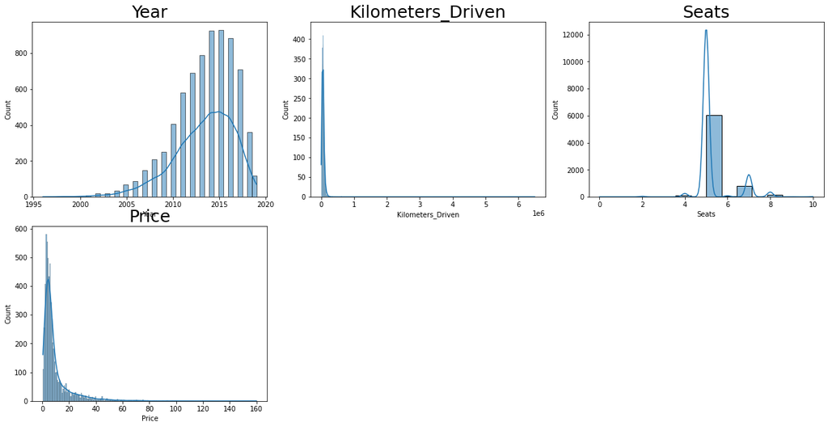

```python
# lets plot histogram of all numerical variables
all_col = cars_data.select_dtypes(include=np.number).columns.tolist()
plt.figure(figsize=(17, 75))

for i in range(len(all_col)):
    plt.subplot(18, 3, i + 1)
    #plt.hist(df[all_col[i]])
    sns.histplot(cars_data[all_col[i]], kde=True)  # you can comment the previous line and run this one to get distribution curves
    plt.tight_layout()
    plt.title(all_col[i], fontsize=25)

plt.show()
```

### Observations

**# Missing values and the object data types are affecting the actual univariate plots of different variables in our data set. Let us do the Missing value tretment and then do our EDA for Univariate and Bivariate deeply**

## Missing value Treatment

```python
#Checking for the count of null values and zeros in Seats column
print(cars_data[cars_data['Seats'].isnull()].count())
print(cars_data[cars_data['Seats'] == 0].count())
#replace zero with nan
cars_data.loc[cars_data['Seats'] == 0, 'Seats'] = np.nan
```

```
Name                 53
Location             53
Year                 53
Kilometers_Driven    53
Fuel_Type            53
Transmission         53
Owner_Type           53
Mileage_kmpl_kmkg    53
Engine_CC             7
Power_bhp             7
Seats                 0
New_Price             0
Price                42
Brand                53
Model_Name           53
Model_Name1          53
Indian_Region        53
Brand_Geo            53
dtype: int64
Name                 1
Location             1
Year                 1
Kilometers_Driven    1
Fuel_Type            1
Transmission         1
Owner_Type           1
Mileage_kmpl_kmkg    1
Engine_CC            1
Power_bhp            1
Seats                1
New_Price            0
Price                1
Brand                1
Model_Name           1
Model_Name1          1
Indian_Region        1
Brand_Geo            1
dtype: int64
```

```python
#Replace null values in Seats column with Median value
cars_data['Seats'] = cars_data.groupby(['Name'])['Seats'].apply(lambda x:x.fillna(x.median()))
cars_data['Seats'] = cars_data.groupby(['Brand','Model_Name1'])['Seats'].apply(lambda x: x.fillna(x.median()))
print(cars_data[cars_data['Seats'].isnull()])
```

```
                   Name Location  Year  Kilometers_Driven Fuel_Type  \
2369  Maruti Estilo LXI  Chennai  2008              56000    Petrol
3882  Maruti Estilo LXI  Kolkata  2010              40000    Petrol
5893  Maruti Estilo LXI  Chennai  2008              51000    Petrol

     Transmission Owner_Type Mileage_kmpl_kmkg Engine_CC Power_bhp  Seats  \
2369       Manual     Second              19.5      1061      null    NaN
3882       Manual     Second              19.5      1061      null    NaN
5893       Manual     Second              19.5      1061      null    NaN

     New_Price  Price   Brand  Model_Name Model_Name1 Indian_Region Brand_Geo
2369       NaN   1.50  Maruti  Estilo LXI      Estilo         South     Asian
3882       NaN   2.50  Maruti  Estilo LXI      Estilo          East     Asian
5893       NaN   1.75  Maruti  Estilo LXI      Estilo         South     Asian
```

```python
print(cars_data[cars_data['Model_Name1'] == 'Estilo'].count())
print(cars_data[cars_data['Brand'] == 'Maruti'].median())
```

```
Name                 3
Location             3
Year                 3
Kilometers_Driven    3
Fuel_Type            3
Transmission         3
Owner_Type           3
Mileage_kmpl_kmkg    3
Engine_CC            3
Power_bhp            3
Seats                0
New_Price            0
Price                3
Brand                3
Model_Name           3
Model_Name1          3
Indian_Region        3
Brand_Geo            3
dtype: int64
Year                  2014.00
Kilometers_Driven    52000.00
Mileage_kmpl_kmkg       21.10
Engine_CC             1197.00
Seats                    5.00
Price                    4.15
dtype: float64
```

```python
#Fixing null seat value with the Brand level median value
cars_data['Seats'] = cars_data.groupby(['Brand'])['Seats'].apply(lambda x: x.fillna(x.median()))
print(cars_data[cars_data['Seats'].isnull()].count())
#Categorizing Seats column into three buckets
cars_data['Seats_Count'] = cars_data['Seats']
cars_data['Seats_Count'] = cars_data['Seats_Count'].replace([2.0,4.0],'Small')
cars_data['Seats_Count'] = cars_data['Seats_Count'].replace([5.0],'Economy')
cars_data['Seats_Count'] = cars_data['Seats_Count'].replace([6.0,7.0,8.0,9.0,10.0],'Large')
print(cars_data.head())
#Convert the data type of Seats column
#cars_data['Seats'] = cars_data['Seats'].astype('category')
cars_data['Seats_Count'] = cars_data['Seats_Count'].astype('category')
```

```
Name                 0
Location             0
Year                 0
Kilometers_Driven    0
Fuel_Type            0
Transmission         0
Owner_Type           0
Mileage_kmpl_kmkg    0
Engine_CC            0
Power_bhp            0
Seats                0
New_Price            0
Price                0
Brand                0
Model_Name           0
Model_Name1          0
Indian_Region        0
Brand_Geo            0
dtype: int64
                               Name    Location  Year  Kilometers_Driven  \
0            Maruti Wagon R LXI CNG      Mumbai  2010              72000
1  Hyundai Creta 1.6 CRDi SX Option        Pune  2015              41000
2                      Honda Jazz V     Chennai  2011              46000
3                 Maruti Ertiga VDI     Chennai  2012              87000
4   Audi A4 New 2.0 TDI Multitronic  Coimbatore  2013              40670

  Fuel_Type Transmission Owner_Type Mileage_kmpl_kmkg Engine_CC Power_bhp  \
0       CNG       Manual      First              26.6       998     58.16
1    Diesel       Manual      First             19.67      1582     126.2
2    Petrol       Manual      First              18.2      1199      88.7
3    Diesel       Manual      First             20.77      1248     88.76
4    Diesel    Automatic     Second              15.2      1968     140.8

   Seats  New_Price  Price    Brand                  Model_Name Model_Name1  \
0    5.0        NaN   1.75   Maruti             Wagon R LXI CNG       Wagon
1    5.0        NaN  12.50  Hyundai    Creta 1.6 CRDi SX Option       Creta
2    5.0  8.61 Lakh   4.50    Honda                      Jazz V        Jazz
3    7.0        NaN   6.00   Maruti                  Ertiga VDI      Ertiga
4    5.0        NaN  17.74     Audi  A4 New 2.0 TDI Multitronic          A4

  Indian_Region Brand_Geo Seats_Count
0          West     Asian     Economy
1          West     Asian     Economy
2         South     Asian     Economy
3         South     Asian       Large
4         South  European     Economy
```

```python
#Check the null values and zero value in the column Mileage
print(cars_data[cars_data['Mileage_kmpl_kmkg'].isnull()].count())
print(cars_data[cars_data['Mileage_kmpl_kmkg'] == '0.0'].count())
#replace zero with nan
cars_data.loc[cars_data['Mileage_kmpl_kmkg'] == '0.0', 'Mileage_kmpl_kmkg'] = np.nan
print(cars_data[cars_data['Mileage_kmpl_kmkg'] == '0.0'].count())
```

```
Name                 2
Location             2
Year                 2
Kilometers_Driven    2
Fuel_Type            2
Transmission         2
Owner_Type           2
Mileage_kmpl_kmkg    0
Engine_CC            2
Power_bhp            2
Seats                2
New_Price            1
Price                2
Brand                2
Model_Name           2
Model_Name1          2
Indian_Region        2
Brand_Geo            2
Seats_Count          2
dtype: int64
Name                 81
Location             81
Year                 81
Kilometers_Driven    81
Fuel_Type            81
Transmission         81
Owner_Type           81
Mileage_kmpl_kmkg    81
Engine_CC            69
Power_bhp            69
Seats                81
New_Price             4
Price                68
Brand                81
Model_Name           81
Model_Name1          81
Indian_Region        81
Brand_Geo            81
Seats_Count          81
dtype: int64
Name                 0
Location             0
Year                 0
Kilometers_Driven    0
Fuel_Type            0
Transmission         0
Owner_Type           0
Mileage_kmpl_kmkg    0
Engine_CC            0
Power_bhp            0
Seats                0
New_Price            0
Price                0
Brand                0
Model_Name           0
Model_Name1          0
Indian_Region        0
Brand_Geo            0
Seats_Count          0
dtype: int64
```

```python
#Fill up the Mileage null values with grouped median values
cars_data['Mileage_kmpl_kmkg'] = cars_data.groupby(['Brand','Fuel_Type','Seats'])['Mileage_kmpl_kmkg'].apply(lambda x:x.fillna(x.median()))
print(cars_data[cars_data['Mileage_kmpl_kmkg'].isnull()])
cars_data['Mileage_kmpl_kmkg'] = cars_data.groupby(['Fuel_Type','Seats'])['Mileage_kmpl_kmkg'].apply(lambda x:x.fillna(x.median()))
print(cars_data[cars_data['Mileage_kmpl_kmkg'].isnull()])
cars_data['Mileage_kmpl_kmkg'] = cars_data.groupby(['Brand','Seats'])['Mileage_kmpl_kmkg'].apply(lambda x:x.fillna(x.median()))
print(cars_data[cars_data['Mileage_kmpl_kmkg'].isnull()])
cars_data['Mileage_kmpl_kmkg'] = cars_data.groupby(['Seats'])['Mileage_kmpl_kmkg'].apply(lambda x:x.fillna(x.median()))
print(cars_data[cars_data['Mileage_kmpl_kmkg'].isnull()].count())
#Convert the data type of Mileage
cars_data['Mileage_kmpl_kmkg'] = cars_data['Mileage_kmpl_kmkg'].astype('float64')
```

```
                                              Name    Location  Year  \
915                            Smart Fortwo CDI AT        Pune  2008
1460  Land Rover Range Rover Sport 2005 2012 Sport  Coimbatore  2008
4446                          Mahindra E Verito D4     Chennai  2016
4904                     Toyota Prius 2009-2016 Z4      Mumbai  2011

      Kilometers_Driven Fuel_Type Transmission Owner_Type Mileage_kmpl_kmkg  \
915              103000    Diesel    Automatic     Second               NaN
1460              69078    Petrol       Manual      First               NaN
4446              50000  Electric    Automatic      First               NaN
4904              44000  Electric    Automatic      First               NaN

     Engine_CC Power_bhp  Seats   New_Price  Price       Brand  \
915        799      null    2.0         NaN   3.00       Smart
1460       NaN       NaN    5.0         NaN  40.88  Land Rover
4446        72        41    5.0  13.58 Lakh  13.00    Mahindra
4904      1798        73    5.0         NaN  12.75      Toyota

                                   Model_Name Model_Name1 Indian_Region  \
915                             Fortwo CDI AT      Fortwo          West
1460  Rover Range Rover Sport 2005 2012 Sport       Rover         South
4446                              E Verito D4           E         South
4904                       Prius 2009-2016 Z4       Prius          West

     Brand_Geo Seats_Count
915      Smart       Small
1460  European     Economy
4446     Asian     Economy
4904     Asian     Economy
                           Name Location  Year  Kilometers_Driven Fuel_Type  \
915         Smart Fortwo CDI AT     Pune  2008             103000    Diesel
4446       Mahindra E Verito D4  Chennai  2016              50000  Electric
4904  Toyota Prius 2009-2016 Z4   Mumbai  2011              44000  Electric

     Transmission Owner_Type Mileage_kmpl_kmkg Engine_CC Power_bhp  Seats  \
915     Automatic     Second               NaN       799      null    2.0
4446    Automatic      First               NaN        72        41    5.0
4904    Automatic      First               NaN      1798        73    5.0

       New_Price  Price     Brand          Model_Name Model_Name1  \
```

[output cut: 24 more lines]

```
Transmission         0
Owner_Type           0
Mileage_kmpl_kmkg    0
Engine_CC            0
Power_bhp            0
Seats                0
New_Price            0
Price                0
Brand                0
Model_Name           0
Model_Name1          0
Indian_Region        0
Brand_Geo            0
Seats_Count          0
dtype: int64
```

```python
#Check the null values and zero value in the column Engine
print(cars_data[cars_data['Engine_CC'].isnull()].count())
print(cars_data[cars_data['Engine_CC'] == 0 ].count())
#replace nan with median value
cars_data['Engine_CC'] = cars_data.groupby(['Name'])['Engine_CC'].apply(lambda x:x.fillna(x.median()))
print(cars_data[cars_data['Engine_CC'].isnull()].count())
cars_data['Engine_CC'] = cars_data.groupby(['Brand','Model_Name1','Fuel_Type'])['Engine_CC'].apply(lambda x:x.fillna(x.median()))
cars_data['Engine_CC'] = cars_data.groupby(['Brand','Seats'])['Engine_CC'].apply(lambda x:x.fillna(x.median()))
print(cars_data[cars_data['Engine_CC'].isnull()].count())
#Convert Engine data type to float
cars_data['Engine_CC'] = cars_data['Engine_CC'].astype('float64')
```

```
Name                 46
Location             46
Year                 46
Kilometers_Driven    46
Fuel_Type            46
Transmission         46
Owner_Type           46
Mileage_kmpl_kmkg    46
Engine_CC             0
Power_bhp             0
Seats                46
New_Price             0
Price                36
Brand                46
Model_Name           46
Model_Name1          46
Indian_Region        46
Brand_Geo            46
Seats_Count          46
dtype: int64
Name                 0
Location             0
Year                 0
Kilometers_Driven    0
Fuel_Type            0
Transmission         0
Owner_Type           0
Mileage_kmpl_kmkg    0
Engine_CC            0
Power_bhp            0
Seats                0
New_Price            0
Price                0
Brand                0
Model_Name           0
Model_Name1          0
Indian_Region        0
Brand_Geo            0
Seats_Count          0
dtype: int64
```

[output cut: 25 more lines]

```
Transmission         0
Owner_Type           0
Mileage_kmpl_kmkg    0
Engine_CC            0
Power_bhp            0
Seats                0
New_Price            0
Price                0
Brand                0
Model_Name           0
Model_Name1          0
Indian_Region        0
Brand_Geo            0
Seats_Count          0
dtype: int64
```

```python
#Check the null values and zero value in the column Power
print(cars_data[cars_data['Power_bhp'].isnull()].count())
print(cars_data[cars_data['Power_bhp'] == 'null' ].count())
print(cars_data[cars_data['Power_bhp'] == 'Null' ].count())
print(cars_data[cars_data['Power_bhp'] == '?' ].count())
print(cars_data[cars_data['Power_bhp'] == 'None' ].count())
print(cars_data[cars_data['Power_bhp'].isnull()])
#replace null with nan
cars_data.loc[cars_data['Power_bhp'] == 'null', 'Power_bhp'] = np.nan
print(cars_data[cars_data['Power_bhp'] == 'null'].count())
print(cars_data[cars_data['Power_bhp'].isnull()].count())
#replace nan values with median
cars_data['Power_bhp'] = cars_data.groupby(['Name'])['Power_bhp'].apply(lambda x:x.fillna(x.median()))
cars_data['Power_bhp'] = cars_data.groupby(['Brand','Model_Name1','Fuel_Type'])['Power_bhp'].apply(lambda x:x.fillna(x.median()))
cars_data['Power_bhp'] = cars_data.groupby(['Brand','Fuel_Type'])['Power_bhp'].apply(lambda x:x.fillna(x.median()))
#convert the Power column data type to float
cars_data['Power_bhp'] = cars_data['Power_bhp'].astype('float64')
```

```
Name                 46
Location             46
Year                 46
Kilometers_Driven    46
Fuel_Type            46
Transmission         46
Owner_Type           46
Mileage_kmpl_kmkg    46
Engine_CC            46
Power_bhp             0
Seats                46
New_Price             0
Price                36
Brand                46
Model_Name           46
Model_Name1          46
Indian_Region        46
Brand_Geo            46
Seats_Count          46
dtype: int64
Name                 129
Location             129
Year                 129
Kilometers_Driven    129
Fuel_Type            129
Transmission         129
Owner_Type           129
Mileage_kmpl_kmkg    129
Engine_CC            129
Power_bhp            129
Seats                129
New_Price              0
Price                107
Brand                129
Model_Name           129
Model_Name1          129
Indian_Region        129
Brand_Geo            129
Seats_Count          129
dtype: int64
```

[output cut: 324 more lines]

```
Transmission         175
Owner_Type           175
Mileage_kmpl_kmkg    175
Engine_CC            175
Power_bhp              0
Seats                175
New_Price              0
Price                143
Brand                175
Model_Name           175
Model_Name1          175
Indian_Region        175
Brand_Geo            175
Seats_Count          175
dtype: int64
```

```python
print(cars_data[cars_data['Power_bhp'].isnull()])
```

```
                                              Name    Location  Year  \
915                            Smart Fortwo CDI AT        Pune  2008
1460  Land Rover Range Rover Sport 2005 2012 Sport  Coimbatore  2008
6216             Hindustan Motors Contessa 2.0 DSL        Pune  1996

      Kilometers_Driven Fuel_Type Transmission Owner_Type  Mileage_kmpl_kmkg  \
915              103000    Diesel    Automatic     Second              10.37
1460              69078    Petrol       Manual      First              18.00
6216              65000    Diesel       Manual     Second              14.10

      Engine_CC  Power_bhp  Seats New_Price  Price       Brand  \
915       799.0        NaN    2.0       NaN   3.00       Smart
1460     2179.0        NaN    5.0       NaN  40.88  Land Rover
6216     1995.0        NaN    5.0       NaN    NaN   Hindustan

                                   Model_Name Model_Name1 Indian_Region  \
915                             Fortwo CDI AT      Fortwo          West
1460  Rover Range Rover Sport 2005 2012 Sport       Rover         South
6216                  Motors Contessa 2.0 DSL      Motors          West

      Brand_Geo Seats_Count
915       Smart       Small
1460   European     Economy
6216  Hindustan     Economy
```

```python
#As there are too many field imputation with median values dropping the above three heavily manipulated rows
cars_data = cars_data.drop([915,1460,6216])
#Dropping off Ambassador as it has only one row and has a high p values in modelling
#cars_data = cars_data.drop([1221])
```

```python
#Check the null values and zero value in the column Price
print(cars_data[cars_data['Price'].isnull()].count())
print(cars_data[cars_data['Price'] == 'null' ].count())
print(cars_data[cars_data['Price'] == 'Null' ].count())
print(cars_data[cars_data['Price'] == '?' ].count())
print(cars_data[cars_data['Price'] == 'None' ].count())
#replace nan values with median
cars_data['Price'] = cars_data.groupby(['Name','Year'])['Price'].apply(lambda x:x.fillna(x.median()))
cars_data['Price'] = cars_data.groupby(['Brand','Model_Name1','Fuel_Type','Year'])['Price'].apply(lambda x:x.fillna(x.median()))
cars_data['Price'] = cars_data.groupby(['Brand','Fuel_Type','Year'])['Price'].apply(lambda x:x.fillna(x.median()))
cars_data['Price'] = cars_data.groupby(['Brand'])['Price'].apply(lambda x:x.fillna(x.median()))
```

```
Name                 1232
Location             1232
Year                 1232
Kilometers_Driven    1232
Fuel_Type            1232
Transmission         1232
Owner_Type           1232
Mileage_kmpl_kmkg    1232
Engine_CC            1232
Power_bhp            1232
Seats                1232
New_Price             182
Price                   0
Brand                1232
Model_Name           1232
Model_Name1          1232
Indian_Region        1232
Brand_Geo            1232
Seats_Count          1232
dtype: int64
Name                 0
Location             0
Year                 0
Kilometers_Driven    0
Fuel_Type            0
Transmission         0
Owner_Type           0
Mileage_kmpl_kmkg    0
Engine_CC            0
Power_bhp            0
Seats                0
New_Price            0
Price                0
Brand                0
Model_Name           0
Model_Name1          0
Indian_Region        0
Brand_Geo            0
Seats_Count          0
dtype: int64
```

[output cut: 45 more lines]

```
Transmission         0
Owner_Type           0
Mileage_kmpl_kmkg    0
Engine_CC            0
Power_bhp            0
Seats                0
New_Price            0
Price                0
Brand                0
Model_Name           0
Model_Name1          0
Indian_Region        0
Brand_Geo            0
Seats_Count          0
dtype: int64
```

```python
print(cars_data[cars_data['Price'].isnull()])
#As there is no relevant data to match median price dropping the 7067 index row
cars_data = cars_data.drop([7067])
print(cars_data[cars_data['Price'].isnull()])
```

```
                  Name   Location  Year  Kilometers_Driven Fuel_Type  \
7067  OpelCorsa 1.4Gsi  Hyderabad  2005              50000    Petrol

     Transmission Owner_Type  Mileage_kmpl_kmkg  Engine_CC  Power_bhp  Seats  \
7067       Manual     Second               14.2     1389.0       88.0    5.0

     New_Price  Price      Brand Model_Name Model_Name1 Indian_Region  \
7067       NaN    NaN  OpelCorsa     1.4Gsi      1.4Gsi         South

      Brand_Geo Seats_Count
7067  OpelCorsa     Economy
Empty DataFrame
Columns: [Name, Location, Year, Kilometers_Driven, Fuel_Type, Transmission, Owner_Type, Mileage_kmpl_kmkg, Engine_CC, Power_bhp, Seats, New_Price, Price, Brand, Model_Name, Model_Name1, Indian_Region, Brand_Geo, Seats_Count]
Index: []
```

```python
cars_data.info()
```

```
<class 'pandas.core.frame.DataFrame'>
Int64Index: 7248 entries, 0 to 7252
Data columns (total 19 columns):
 #   Column             Non-Null Count  Dtype
---  ------             --------------  -----
 0   Name               7248 non-null   object
 1   Location           7248 non-null   object
 2   Year               7248 non-null   int64
 3   Kilometers_Driven  7248 non-null   int64
 4   Fuel_Type          7248 non-null   object
 5   Transmission       7248 non-null   object
 6   Owner_Type         7248 non-null   object
 7   Mileage_kmpl_kmkg  7248 non-null   float64
 8   Engine_CC          7248 non-null   float64
 9   Power_bhp          7248 non-null   float64
 10  Seats              7248 non-null   float64
 11  New_Price          1006 non-null   object
 12  Price              7248 non-null   float64
 13  Brand              7248 non-null   object
 14  Model_Name         7248 non-null   object
 15  Model_Name1        7248 non-null   object
 16  Indian_Region      7248 non-null   object
 17  Brand_Geo          7248 non-null   object
 18  Seats_Count        7248 non-null   category
dtypes: category(1), float64(5), int64(2), object(11)
memory usage: 1.1+ MB
```

```python
#Dropping New_Price column as it has only 15% of not null data
cars_data = cars_data.drop(columns = 'New_Price')
```

```python
print(cars_data.info())
```

```
<class 'pandas.core.frame.DataFrame'>
Int64Index: 7248 entries, 0 to 7252
Data columns (total 18 columns):
 #   Column             Non-Null Count  Dtype
---  ------             --------------  -----
 0   Name               7248 non-null   object
 1   Location           7248 non-null   object
 2   Year               7248 non-null   int64
 3   Kilometers_Driven  7248 non-null   int64
 4   Fuel_Type          7248 non-null   object
 5   Transmission       7248 non-null   object
 6   Owner_Type         7248 non-null   object
 7   Mileage_kmpl_kmkg  7248 non-null   float64
 8   Engine_CC          7248 non-null   float64
 9   Power_bhp          7248 non-null   float64
 10  Seats              7248 non-null   float64
 11  Price              7248 non-null   float64
 12  Brand              7248 non-null   object
 13  Model_Name         7248 non-null   object
 14  Model_Name1        7248 non-null   object
 15  Indian_Region      7248 non-null   object
 16  Brand_Geo          7248 non-null   object
 17  Seats_Count        7248 non-null   category
dtypes: category(1), float64(5), int64(2), object(10)
memory usage: 1.0+ MB
None
```

## Data Types Conversion

```python
#Convert the data types of the object variables
cars_data['Name'] = cars_data['Name'].astype('string')
cars_data['Location'] = cars_data['Location'].astype('category')
cars_data['Fuel_Type'] = cars_data['Fuel_Type'].astype('category')
cars_data['Transmission'] = cars_data['Transmission'].astype('category')
cars_data['Owner_Type'] = cars_data['Owner_Type'].astype('category')
cars_data['Brand'] = cars_data['Brand'].astype('category')
cars_data['Model_Name'] = cars_data['Model_Name'].astype('string')
cars_data['Indian_Region'] = cars_data['Indian_Region'].astype('category')
cars_data['Model_Name1'] = cars_data['Model_Name1'].astype('string')
cars_data['Brand_Geo'] = cars_data['Brand_Geo'].astype('category')
```

## Univariate Analysis

### Hist/Count Plot of Numeric variables

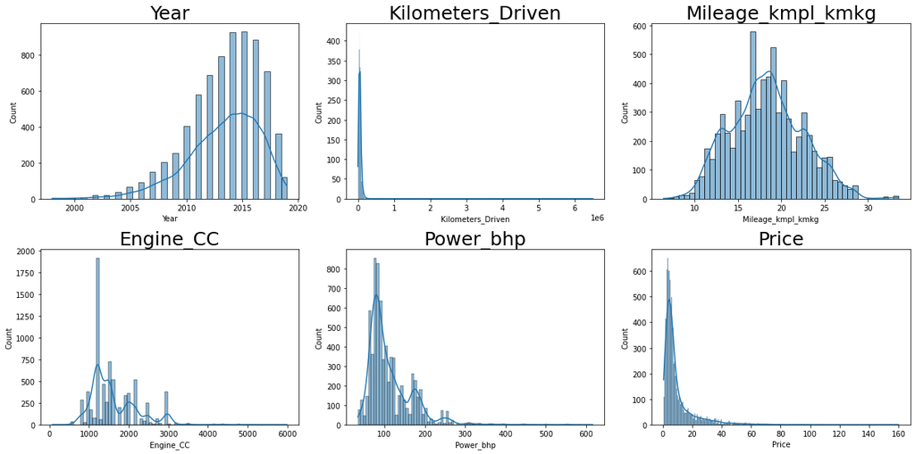

```python
# lets plot histogram of all numerical variables
all_col = cars_data.select_dtypes(include=np.number).columns.tolist()
all_col.remove('Seats')
plt.figure(figsize=(17, 75))

for i in range(len(all_col)):
    plt.subplot(18, 3, i + 1)
    #plt.hist(df[all_col[i]])
    sns.histplot(cars_data[all_col[i]], kde=True)  # you can comment the previous line and run this one to get distribution curves
    plt.tight_layout()
    plt.title(all_col[i], fontsize=25)

plt.show()
```

### Observations

**2.Power_bhp is right skewed indicating there are some cars with very high power and some with very low introducting the right tail.**

**3.Year is left skewed indicating that the data has more young aged cars than old ones.**

**4.Let us apply log and see if the power column skew gets treated. Log has kind of helped with the skewness. Let us re-check this during data modelling.**

**5.Mileage is nearly a normal distribution.**

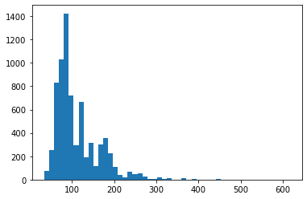

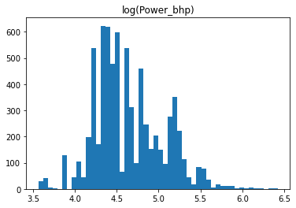

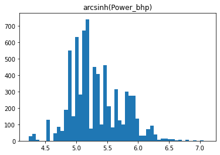

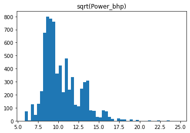

```python
plt.hist((cars_data['Power_bhp']), 50)
plt.show()
plt.hist(np.log(cars_data['Power_bhp']+1), 50)
plt.title('log(Power_bhp)')
plt.show()
plt.hist(np.arcsinh(cars_data['Power_bhp']), 50)
plt.title('arcsinh(Power_bhp)')
plt.show()
plt.hist(np.sqrt(cars_data['Power_bhp']), 50)
plt.title('sqrt(Power_bhp)')
plt.show()
```

```python
#Function to plot both box and histogram together
def histogram_boxplot(feature, figsize=(15, 10), bins=None):
    """Boxplot and histogram combined
    feature: 1-d feature array
    figsize: size of fig (default (9,8))
    bins: number of bins (default None / auto)
    """
    sns.set(font_scale=2)  # setting the font scale for seaborn
    f2, (ax_box2, ax_hist2) = plt.subplots(
        nrows=2,  # Number of rows of the subplot grid=2
        sharex=True,  # x-axis will be shared among all subplots
        gridspec_kw={"height_ratios": (0.25, 0.75)},
        figsize=figsize,
    )  # creating the 2 subplots
    sns.boxplot(
        feature, ax=ax_box2, showmeans=True, color="red"
    )  # boxplot will be created and a star will indicate the mean value of the column
    sns.distplot(feature, kde=F, ax=ax_hist2, bins=bins) if bins else sns.distplot(
        feature, kde=False, ax=ax_hist2
    )  # For histogram
    ax_hist2.axvline(
        feature.mean(), color="g", linestyle="--"
    )  # Add mean to the histogram
    ax_hist2.axvline(
        feature.median(), color="black", linestyle="-"
    )  # Add median to the histogram
```

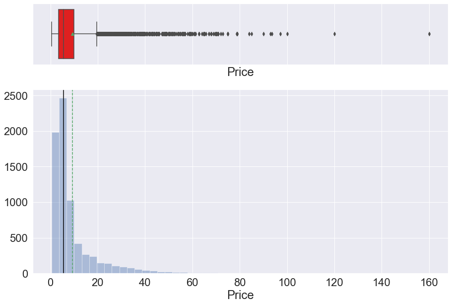

```python
histogram_boxplot(cars_data.Price)
```

### Observations

**# There are sizable outliers beyond 20 lakhs.**

```python
cars_data['Price'].max()
```

```
160.0
```

```
                               Name    Location  Year  Kilometers_Driven  \
0            Maruti Wagon R LXI CNG      Mumbai  2010              72000
1  Hyundai Creta 1.6 CRDi SX Option        Pune  2015              41000
2                      Honda Jazz V     Chennai  2011              46000
3                 Maruti Ertiga VDI     Chennai  2012              87000
4   Audi A4 New 2.0 TDI Multitronic  Coimbatore  2013              40670

  Fuel_Type Transmission Owner_Type  Mileage_kmpl_kmkg  Engine_CC  Power_bhp  \
0       CNG       Manual      First              26.60      998.0      58.16
1    Diesel       Manual      First              19.67     1582.0     126.20
2    Petrol       Manual      First              18.20     1199.0      88.70
3    Diesel       Manual      First              20.77     1248.0      88.76
4    Diesel    Automatic     Second              15.20     1968.0     140.80

   Seats  Price    Brand                  Model_Name Model_Name1  \
0    5.0   1.75   Maruti             Wagon R LXI CNG       Wagon
1    5.0  12.50  Hyundai    Creta 1.6 CRDi SX Option       Creta
2    5.0   4.50    Honda                      Jazz V        Jazz
3    7.0   6.00   Maruti                  Ertiga VDI      Ertiga
4    5.0  17.74     Audi  A4 New 2.0 TDI Multitronic          A4

  Indian_Region Brand_Geo Seats_Count Price_Range
0          West     Asian     Economy         Low
1          West     Asian     Economy        High
2         South     Asian     Economy         Low
3         South     Asian       Large         Low
4         South  European     Economy        High
```

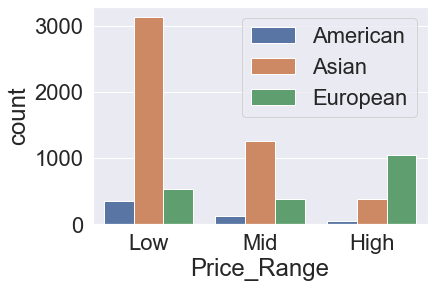

```python
#Binning the Price to plot the distribution in low,mid and high range buckets
cars_data['Price_Range'] = pd.cut(x = cars_data['Price'],bins = [0,6,12,160], labels = ['Low','Mid','High'])
print(cars_data.head())
#Count Plot of Price
sns.countplot(x = "Price_Range", data= cars_data, hue = 'Brand_Geo')
plt.legend(bbox_to_anchor = (1,1))
plt.figure(figsize=(15, 5))
```

### Observations

**1. Low priced cars(0 t0 6 lakhs) dominated by Asian Brands are the majority with nearly 60% of the data set.**

**2. Mid priced cars(6 to 12 lakhs) dominated by Asian Brands contribute around 20% of the data set.**

## Countplot of categorical variables

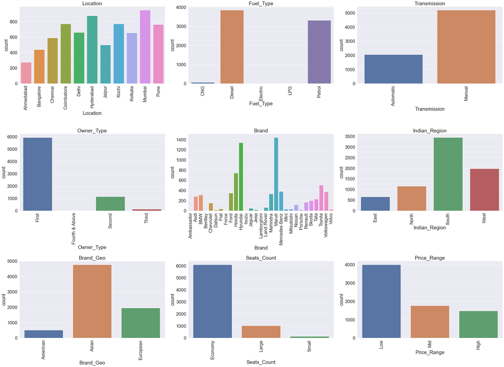

```python
# lets plot countplot of all categorical variables

all_col_cat = cars_data.select_dtypes(include = 'category').columns.tolist()
plt.figure(figsize=(34, 150))

for i in range(len(all_col_cat)):
    plt.subplot(18, 3, i + 1)
    sns.countplot(cars_data[all_col_cat[i]])  # you can comment the previous line and run this one to get distribution curves
    plt.xticks(rotation = 90)
    plt.tight_layout()
    plt.title(all_col_cat[i], fontsize=25)

plt.show()
```

### Observations

**1.Brand Maruti seems to be the most commonly preffered and has the highest count of around 1450 follower by Hyundai with 1350.**

**2.Southern part of India has the maximum usage of cars.**

**3.Owner Type First has the maximum number of data entries.**

**4.Asian cars are the most sold variety in India.**

**5.Five seater cars are highly dominating around 85% of our data set indicating that is most preffered among all in India.**

**6.Diesel and Petrol cars are the most used cars in India.**

**7.Manual cars are preffered over Automatic cars.**

```python
# Function to create barplots that indicate count for each category.


def count_on_bar(data, z):
    """
    plot
    feature: categorical feature
    the function won't work if a column is passed in hue parameter
    """

    total = len(data[z])  # length of the column
    plt.figure(figsize=(15, 5))
    plt.xticks(rotation=90)
    ax = sns.countplot(data=data, x=z, palette="Paired")
    for p in ax.patches:
        percentage = p.get_height()  # count of each class of the category
        x = p.get_x() + p.get_width() / total + 0.2  # width of the plot
        y = p.get_y() + p.get_height()  # height of the plot

        ax.annotate(percentage, (x, y), size=12)  # annotate the percentage
    plt.show()  # show the plot
```

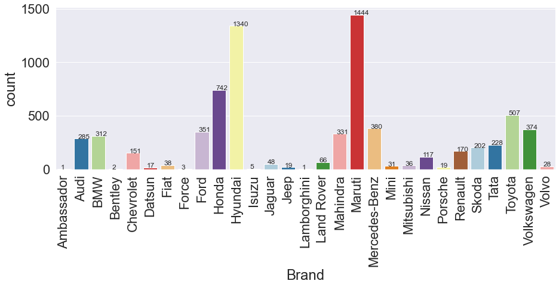

```python
#Check the Brand data count in a closer look
count_on_bar(cars_data, 'Brand')
#sns.countplot(x = 'Brand', data = cars_data)
#plt.xticks(rotation = 90)
```

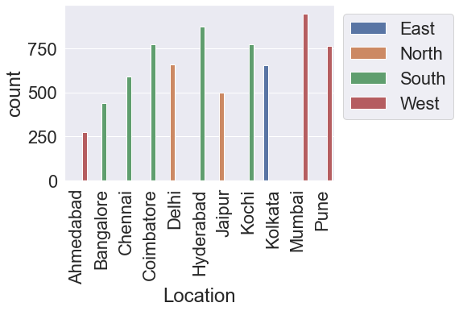

```python
#Bigger view of the univariate plot
sns.countplot(x = 'Location' ,hue = 'Indian_Region', data = cars_data)
plt.xticks(rotation = 90)
plt.legend(bbox_to_anchor = (1,1))
```

## Bivariate Analysis

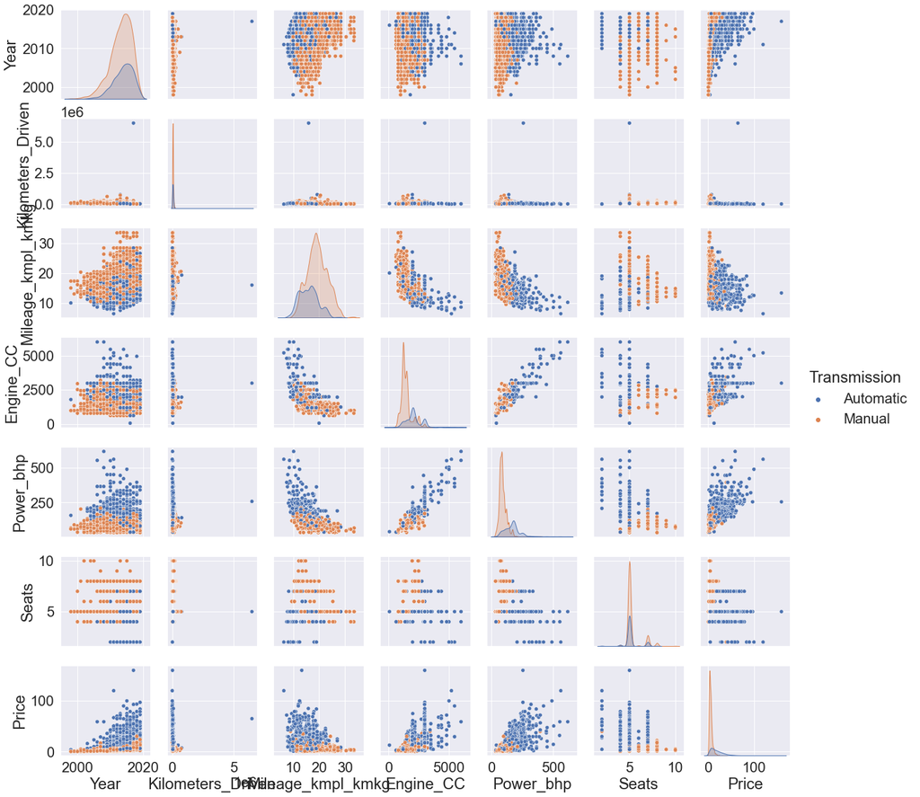

```python
sns.pairplot(data = cars_data, hue = 'Transmission')
```

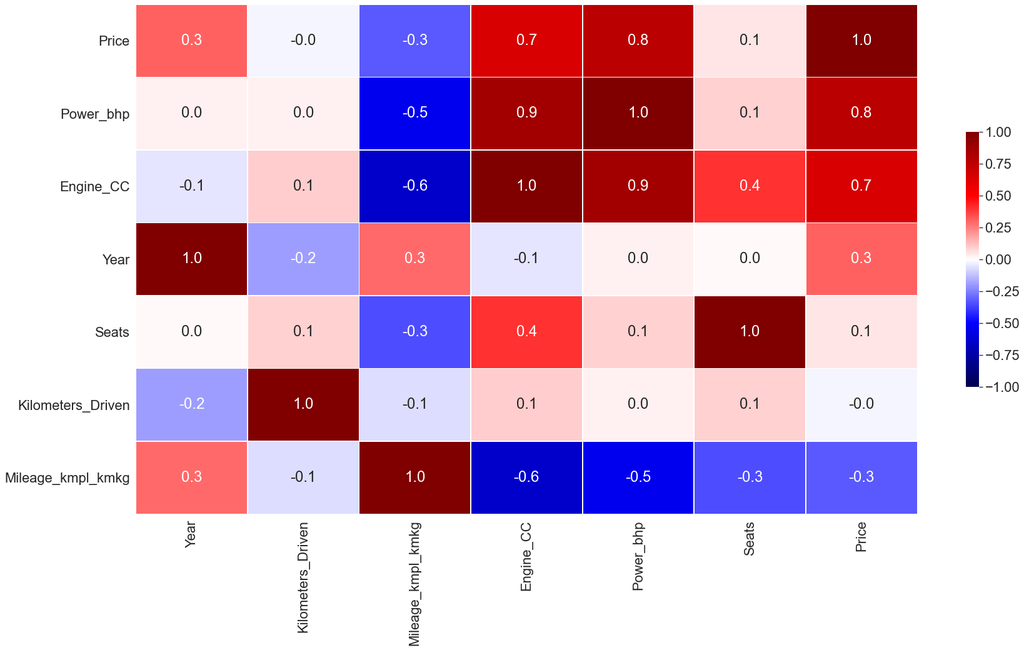

```python
#Plot the heat map to check the correlation between numeric variables
numeric_columns = cars_data.select_dtypes(include=np.number).columns.tolist()
corr = (
    cars_data[numeric_columns].corr().sort_values(by=["Price"], ascending=False)
)  # sorting correlations w.r.t Price

# Set up the matplotlib figure
f, ax = plt.subplots(figsize=(28, 15))

# Draw the heatmap with the mask and correct aspect ratio
sns.heatmap(
    corr,
    cmap="seismic",
    annot=True,
    fmt=".1f",
    vmin=-1,
    vmax=1,
    center=0,
    square=False,
    linewidths=0.7,
    cbar_kws={"shrink": 0.5},
)
```

### Observations

**1.Power_bhp and Engine_CC are strongly correlated.We can drop one of these columns during modelling.**

**2.Price and Engine have a strong positive correlation.**

**3.Price and power is positively correlated.**

**4.As the power of the car increases the Price also increases.**

**5.Engine and Mileage are negatively correlated.Bigger Engine yields less Mileage.**

[output not shown]

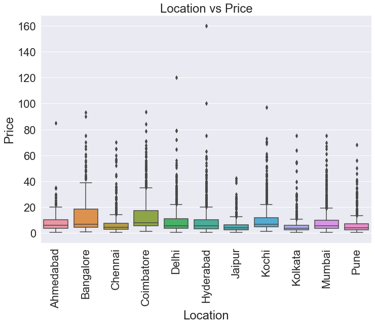

```python
fig, ax = plt.subplots()
# the size of A4 paper
fig.set_size_inches(11.7, 8.27)
sns.boxplot(x = 'Location', y = 'Price' , data = cars_data)
plt.title('Location vs Price')
plt.xticks(rotation = 90)
```

### Observations

**# Bangalore and Coimbatore Location specifically in Southern India can be targetted for luxury cars that are highly priced.**

## EDA - Bivariate - Price vs Brand and Region

```
(array([ 0,  1,  2,  3,  4,  5,  6,  7,  8,  9, 10, 11, 12, 13, 14, 15, 16,
        17, 18, 19, 20, 21, 22, 23, 24, 25, 26, 27, 28]),
 [Text(0, 0, 'Ambassador'),
```

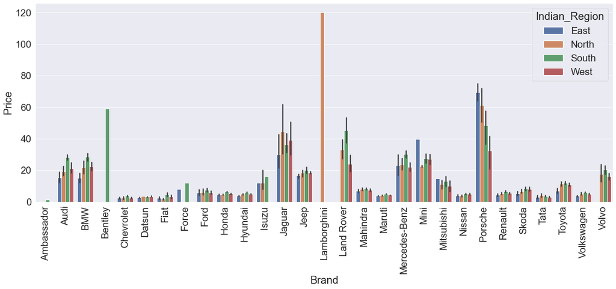

```python
#Bar plot to check the Brand Price region wise
fig, ax = plt.subplots()
# the size of A4 paper
fig.set_size_inches(23.4, 8.27)
sns.barplot(x = 'Brand', y = 'Price' , hue = 'Indian_Region',data = cars_data)
plt.xticks(rotation = 90)
```

```
(array([ 0,  1,  2,  3,  4,  5,  6,  7,  8,  9, 10, 11, 12, 13, 14, 15, 16,
        17, 18, 19, 20, 21, 22, 23, 24, 25, 26, 27, 28]),
 [Text(0, 0, 'Ambassador'),
```

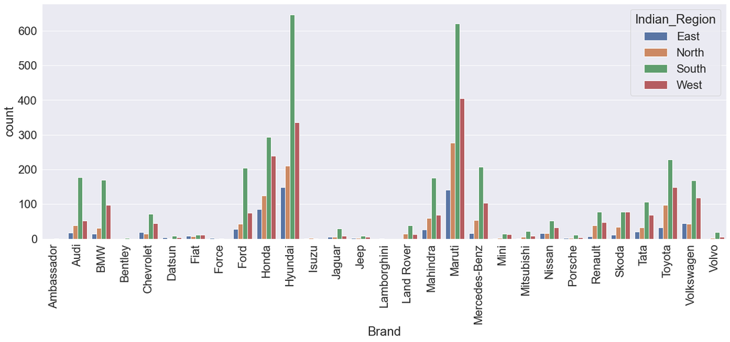

```python
#Bar plot to check the Brand count region wise
fig, ax = plt.subplots()
# the size of A4 paper
fig.set_size_inches(23.4, 8.27)
sns.countplot(x = 'Brand', hue = 'Indian_Region',data = cars_data)
plt.xticks(rotation = 90)
```

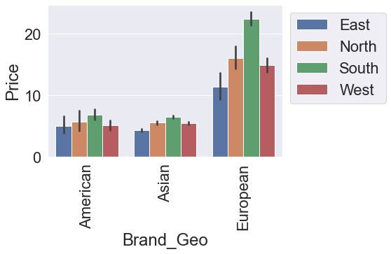

```python
#Plot the bar plot to cross validate Brand vs Brand Geo
fig.set_size_inches(23.4, 8.27)
sns.barplot(x = 'Brand_Geo', y = 'Price' , hue = 'Indian_Region',data = cars_data)
plt.xticks(rotation = 90)
plt.legend(bbox_to_anchor = (1,1))
```

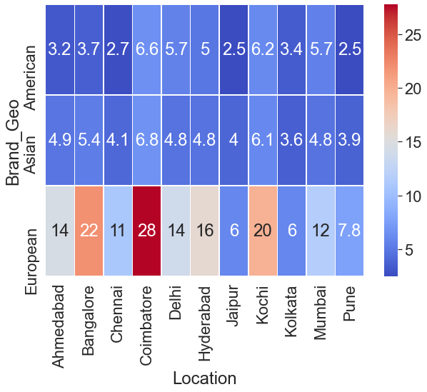

```python
# Plot the Median car price heat maps Brandwise and regionwise
cars_data_hm = cars_data.pivot_table(
    index="Brand_Geo", columns="Location", values="Price", aggfunc=np.median
)

# Draw a heatmap
f, ax = plt.subplots(figsize=(10, 7))
sns.heatmap(cars_data_hm, cmap="coolwarm", linewidths=0.5, annot=True, ax=ax)
```

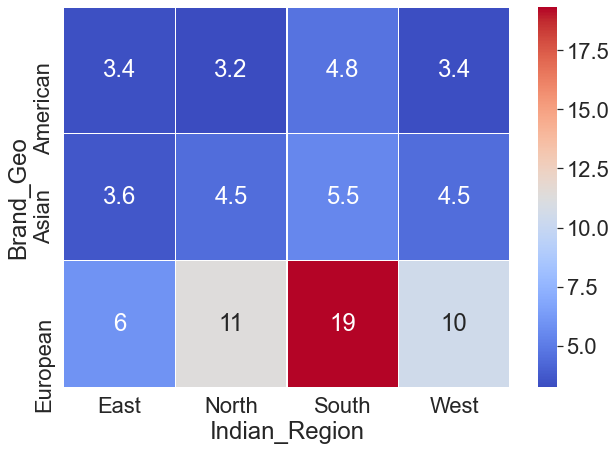

```python
# Plot the Median car price heat maps Brandwise and regionwise
cars_data_hm = cars_data.pivot_table(
    index="Brand_Geo", columns="Indian_Region", values="Price", aggfunc=np.median
)

# Draw a heatmap
f, ax = plt.subplots(figsize=(10, 7))
sns.heatmap(cars_data_hm, cmap="coolwarm", linewidths=0.5, annot=True, ax=ax)
```

### Observations

**1.European cars are highly priced among all other Brands.**

**2.Southern Region in India has high car price compared to other parts of India.**

**3.Coimbatore(South Region) Location has the highest Median car Price in all categories.**

**4.Eastern region has comparitively lower car prices.**

## EDA - Bivariate - Price vs Kilometers_Driven

```python
#Binning the Kilometers_Driven bucket to plot
cars_data['Kilometer_Range'] = pd.cut(x = cars_data['Kilometers_Driven'],bins = [0,10000,20000,30000,40000,50000,60000,70000,80000,90000,100000])
cars_data.head()
```

|  | Name | Location | Year | Kilometers_Driven | Fuel_Type | Transmission | Owner_Type | Mileage_kmpl_kmkg | Engine_CC | Power_bhp | Seats | Price | Brand | Model_Name | Model_Name1 | Indian_Region | Brand_Geo | Seats_Count | Price_Range | Kilometer_Range |
| --- | --- | --- | --- | --- | --- | --- | --- | --- | --- | --- | --- | --- | --- | --- | --- | --- | --- | --- | --- | --- |
| 0 | Maruti Wagon R LXI CNG | Mumbai | 2010 | 72000 | CNG | Manual | First | 26.60 | 998.0 | 58.16 | 5.0 | 1.75 | Maruti | Wagon R LXI CNG | Wagon | West | Asian | Economy | Low | (70000, 80000] |
| 1 | Hyundai Creta 1.6 CRDi SX Option | Pune | 2015 | 41000 | Diesel | Manual | First | 19.67 | 1582.0 | 126.20 | 5.0 | 12.50 | Hyundai | Creta 1.6 CRDi SX Option | Creta | West | Asian | Economy | High | (40000, 50000] |
| 2 | Honda Jazz V | Chennai | 2011 | 46000 | Petrol | Manual | First | 18.20 | 1199.0 | 88.70 | 5.0 | 4.50 | Honda | Jazz V | Jazz | South | Asian | Economy | Low | (40000, 50000] |
| 3 | Maruti Ertiga VDI | Chennai | 2012 | 87000 | Diesel | Manual | First | 20.77 | 1248.0 | 88.76 | 7.0 | 6.00 | Maruti | Ertiga VDI | Ertiga | South | Asian | Large | Low | (80000, 90000] |
| 4 | Audi A4 New 2.0 TDI Multitronic | Coimbatore | 2013 | 40670 | Diesel | Automatic | Second | 15.20 | 1968.0 | 140.80 | 5.0 | 17.74 | Audi | A4 New 2.0 TDI Multitronic | A4 | South | European | Economy | High | (40000, 50000] |

```
(array([0, 1, 2, 3, 4, 5, 6, 7, 8, 9]),
 [Text(0, 0, '(0, 10000]'),
```

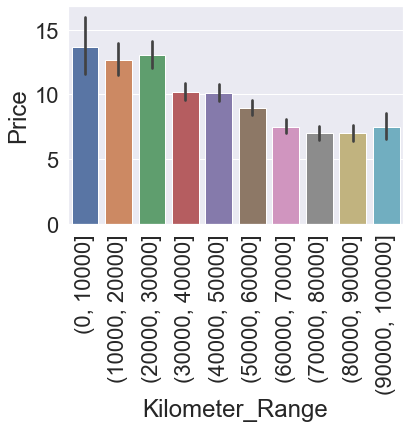

```python
#Plot the barplot to check the correlation
sns.barplot(x = 'Kilometer_Range', y = 'Price', data = cars_data)
plt.xticks(rotation = 90)
```

### Observations

**# Kilometers_Driven is negatively correlated with Price.More the kilometers lesser is the Price**

## EDA - Bivariate - Price vs Year

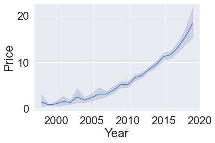

```python
sns.lineplot(x = 'Year', y = 'Price', data=cars_data)
```

### Observations

**# Price vs Year has a strong positive correlation.As the manufacturing year increases the Price also increases. Newer the car higher the Price**

## EDA - Bivariate - Brand vs Transmission Regionwise

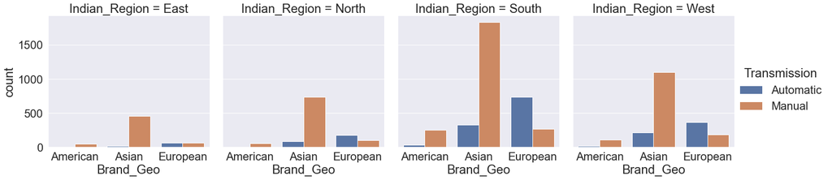

```python
#Plot to check the most used car Brand across regions
plt.figure(figsize=(80, 40))
sns.catplot(x="Brand_Geo", data=cars_data, col="Indian_Region", kind ="count",hue = 'Transmission')
plt.show()
```

### Observations

**1.Manual mode Asian cars are the mostly used in all regions.**

**2.Automatic European cars are preferred over manual.**

**3.Manual American cars are preffered over automatic.**

**4.Southern region tops in all three Brand types usage.**

## Identify the Outliers

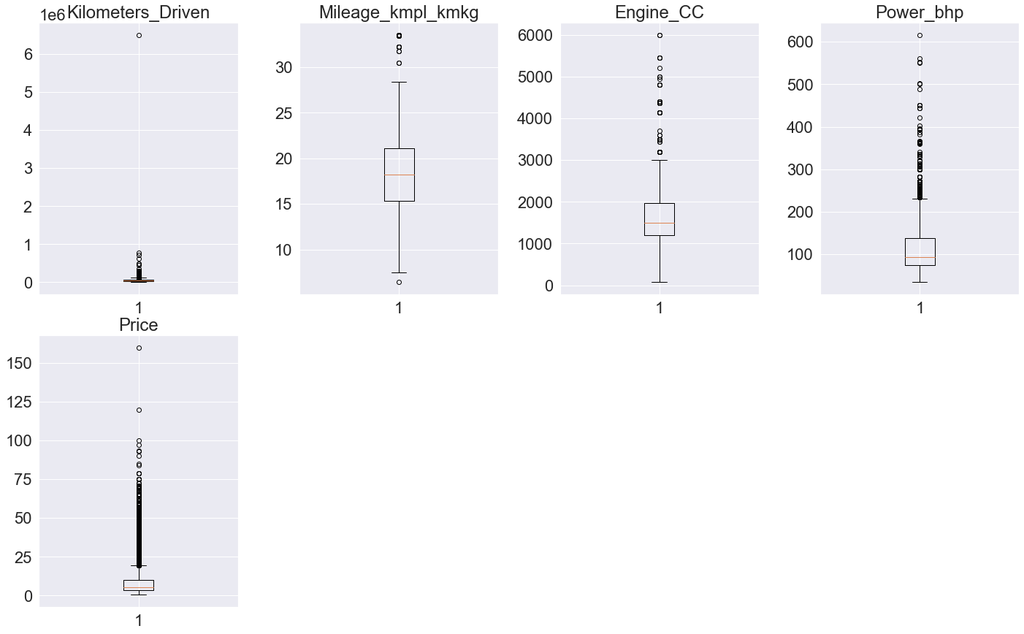

```python
# let's plot the boxplots of all columns to check for outliers
numeric_columns = cars_data.select_dtypes(include=np.number).columns.tolist()
numeric_columns.remove('Year')
numeric_columns.remove("Seats")
plt.figure(figsize=(20, 30))

for i, variable in enumerate(numeric_columns):
    plt.subplot(5, 4, i + 1)
    plt.boxplot(cars_data[variable], whis=1.5)
    plt.tight_layout()
    plt.title(variable)

plt.show()
```

### Observations

**# All the numeric variables have upper outliers.Lets treat and recheck.**

## Outlier Treatment

```python
# Let's treat outliers by flooring and capping
def treat_outliers(cars_data, col):
    """
    treats outliers in a variable
    col: str, name of the numerical variable
    df: dataframe
    col: name of the column
    """
    Q1 = cars_data[col].quantile(0.25)  # 25th quantile
    Q3 = cars_data[col].quantile(0.75)  # 75th quantile
    IQR = Q3 - Q1
    Lower_Whisker = Q1 - 1.5 * IQR
    Upper_Whisker = Q3 + 1.5 * IQR

    # all the values smaller than Lower_Whisker will be assigned the value of Lower_Whisker
    # all the values greater than Upper_Whisker will be assigned the value of Upper_Whisker
    cars_data[col] = np.clip(cars_data[col], Lower_Whisker, Upper_Whisker)

    return cars_data


def treat_outliers_all(cars_data, col_list):
    """
    treat outlier in all numerical variables
    col_list: list of numerical variables
    df: data frame
    """
    for c in col_list:
        cars_data = treat_outliers(cars_data, c)

    return cars_data
```

```python
numerical_col = cars_data.select_dtypes(include=np.number).columns.tolist()
numerical_col.remove("Year")
numerical_col.remove("Seats")
cars_data = treat_outliers_all(cars_data, numerical_col)
```

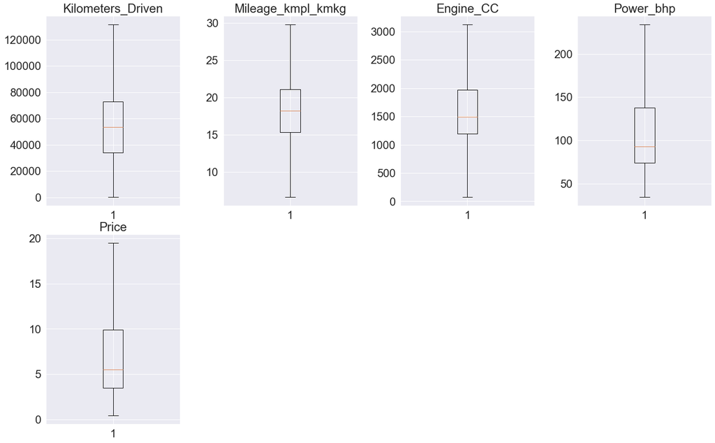

```python
# let's look at box plot to see if outliers have been treated or not
plt.figure(figsize=(20, 30))

for i, variable in enumerate(numeric_columns):
    plt.subplot(5, 4, i + 1)
    plt.boxplot(cars_data[variable], whis=1.5)
    plt.tight_layout()
    plt.title(variable)

plt.show()
```

### Observations

**# All the outliers have been treated successfully.**

## Data Transformation

```python
#Adding log/sqrt column to data set
#cars_data['Log_Power_bhp'] = np.log(cars_data['Power_bhp']+1)
print(cars_data.head())
#cars_data.head()
#cars_data['Log_Year'] = np.log(cars_data['Year']+1)
#cars_data['Log_Kilometers_Driven'] = np.log(cars_data['Kilometers_Driven']+1)
cars_data['Sqrt_Price'] = np.sqrt(cars_data['Price'])
#from sklearn.preprocessing import MinMaxScaler
#scaler = MinMaxScaler()
#cars_data[['Log_Year']] = scaler.fit_transform(cars_data[['Year']])
#cars_data['Log_Year'] = np.exp(cars_data['Log_Year'])
#cars_data[['Log_Kilometers']] = scaler.fit_transform(cars_data[['Kilometers_Driven']])
#cars_data['Log_Kilometers'] = np.exp(cars_data['Log_Kilometers'])
print(cars_data.head())
```

```
                               Name    Location  Year  Kilometers_Driven  \
0            Maruti Wagon R LXI CNG      Mumbai  2010              72000
1  Hyundai Creta 1.6 CRDi SX Option        Pune  2015              41000
2                      Honda Jazz V     Chennai  2011              46000
3                 Maruti Ertiga VDI     Chennai  2012              87000
4   Audi A4 New 2.0 TDI Multitronic  Coimbatore  2013              40670

  Fuel_Type Transmission Owner_Type  Mileage_kmpl_kmkg  Engine_CC  Power_bhp  \
0       CNG       Manual      First              26.60      998.0      58.16
1    Diesel       Manual      First              19.67     1582.0     126.20
2    Petrol       Manual      First              18.20     1199.0      88.70
3    Diesel       Manual      First              20.77     1248.0      88.76
4    Diesel    Automatic     Second              15.20     1968.0     140.80

   Seats  Price    Brand                  Model_Name Model_Name1  \
```

[output cut: 39 more lines]

```python
#Categorizing Owner type further into two buckets
cars_data['Owner_Type'] = cars_data['Owner_Type'].replace(['Second','Third','Fourth & Above'], 'Second & Above')
```

```python
#Copy the data for modelling
cars_data1 = cars_data.copy()
```

```python
#Check the data for all the columns and any null values

cars_data1.info()
```

```
<class 'pandas.core.frame.DataFrame'>
Int64Index: 7248 entries, 0 to 7252
Data columns (total 21 columns):
 #   Column             Non-Null Count  Dtype
---  ------             --------------  -----
 0   Name               7248 non-null   string
 1   Location           7248 non-null   category
 2   Year               7248 non-null   int64
 3   Kilometers_Driven  7248 non-null   int64
 4   Fuel_Type          7248 non-null   category
 5   Transmission       7248 non-null   category
 6   Owner_Type         7248 non-null   category
 7   Mileage_kmpl_kmkg  7248 non-null   float64
 8   Engine_CC          7248 non-null   float64
 9   Power_bhp          7248 non-null   float64
 10  Seats              7248 non-null   float64
 11  Price              7248 non-null   float64
 12  Brand              7248 non-null   category
 13  Model_Name         7248 non-null   string
 14  Model_Name1        7248 non-null   string
 15  Indian_Region      7248 non-null   category
 16  Brand_Geo          7248 non-null   category
 17  Seats_Count        7248 non-null   category
 18  Price_Range        7248 non-null   category
 19  Kilometer_Range    6626 non-null   category
 20  Sqrt_Price         7248 non-null   float64
dtypes: category(10), float64(6), int64(2), string(3)
memory usage: 1.0 MB
```

```python
#Dropping off not needed columns for model
cars_data1.drop(columns=['Model_Name1','Model_Name','Name','Seats','Location','Kilometer_Range','Price_Range'],inplace = True)
```

```python
cars_data1.shape
```

```
(7248, 14)
```

```python
print(cars_data1['Indian_Region'].value_counts())
print(cars_data1['Fuel_Type'].value_counts())
print(cars_data1['Seats_Count'].value_counts())
print(cars_data1[cars_data1['Brand'] == 'Ambassador' ])
```

```
South    3449
West     1986
North    1159
East      654
Name: Indian_Region, dtype: int64
Diesel      3850
Petrol      3322
CNG           62
LPG           12
Electric       2
Name: Fuel_Type, dtype: int64
Economy    6095
Large      1017
Small       136
Name: Seats_Count, dtype: int64
      Year  Kilometers_Driven Fuel_Type Transmission      Owner_Type  \
1221  2003              80000    Diesel       Manual  Second & Above

      Mileage_kmpl_kmkg  Engine_CC  Power_bhp  Price       Brand  \
1221               12.8     1489.0       35.5   1.35  Ambassador

     Indian_Region Brand_Geo Seats_Count  Sqrt_Price
1221         South     Asian     Economy    1.161895
```

## Feature Engineering

### One Hot Encoding of categorical variables

```python
#One hot encoding create dummies for categorical variables
cars_data1 = pd.get_dummies(cars_data1, columns=['Fuel_Type','Indian_Region','Transmission','Seats_Count'])
cars_data1 = pd.get_dummies(cars_data1, columns=['Owner_Type'])
cars_data1 = pd.get_dummies(cars_data1, columns=['Brand_Geo'])
#cars_data1 = pd.get_dummies(cars_data1, columns=['Brand'])
cars_data1.head()
cars_data1.shape
```

```
(7248, 27)
```

```python
# lets build our linear model
# independant variables
X = cars_data1.drop(['Price','Sqrt_Price','Brand','Brand_Geo_American','Fuel_Type_Electric','Indian_Region_East','Transmission_Automatic','Seats_Count_Small','Owner_Type_First'], axis=1)
# the dependent variable
y = cars_data1[['Sqrt_Price']]
print(X.count())
print(y.head())
cars_data1.head()
```

```
Year                         7248
Kilometers_Driven            7248
Mileage_kmpl_kmkg            7248
Engine_CC                    7248
Power_bhp                    7248
Fuel_Type_CNG                7248
Fuel_Type_Diesel             7248
Fuel_Type_LPG                7248
Fuel_Type_Petrol             7248
Indian_Region_North          7248
Indian_Region_South          7248
Indian_Region_West           7248
Transmission_Manual          7248
Seats_Count_Economy          7248
Seats_Count_Large            7248
Owner_Type_Second & Above    7248
Brand_Geo_Asian              7248
Brand_Geo_European           7248
dtype: int64
   Sqrt_Price
0    1.322876
1    3.535534
2    2.121320
3    2.449490
4    4.211888
```

|  | Year | Kilometers_Driven | Mileage_kmpl_kmkg | Engine_CC | Power_bhp | Price | Brand | Sqrt_Price | Fuel_Type_CNG | Fuel_Type_Diesel | Fuel_Type_Electric | Fuel_Type_LPG | Fuel_Type_Petrol | Indian_Region_East | Indian_Region_North | Indian_Region_South | Indian_Region_West | Transmission_Automatic | Transmission_Manual | Seats_Count_Economy | Seats_Count_Large | Seats_Count_Small | Owner_Type_First | Owner_Type_Second & Above | Brand_Geo_American | Brand_Geo_Asian | Brand_Geo_European |
| --- | --- | --- | --- | --- | --- | --- | --- | --- | --- | --- | --- | --- | --- | --- | --- | --- | --- | --- | --- | --- | --- | --- | --- | --- | --- | --- | --- |
| 0 | 2010 | 72000 | 26.60 | 998.0 | 58.16 | 1.75 | Maruti | 1.322876 | 1 | 0 | 0 | 0 | 0 | 0 | 0 | 0 | 1 | 0 | 1 | 1 | 0 | 0 | 1 | 0 | 0 | 1 | 0 |
| 1 | 2015 | 41000 | 19.67 | 1582.0 | 126.20 | 12.50 | Hyundai | 3.535534 | 0 | 1 | 0 | 0 | 0 | 0 | 0 | 0 | 1 | 0 | 1 | 1 | 0 | 0 | 1 | 0 | 0 | 1 | 0 |
| 2 | 2011 | 46000 | 18.20 | 1199.0 | 88.70 | 4.50 | Honda | 2.121320 | 0 | 0 | 0 | 0 | 1 | 0 | 0 | 1 | 0 | 0 | 1 | 1 | 0 | 0 | 1 | 0 | 0 | 1 | 0 |
| 3 | 2012 | 87000 | 20.77 | 1248.0 | 88.76 | 6.00 | Maruti | 2.449490 | 0 | 1 | 0 | 0 | 0 | 0 | 0 | 1 | 0 | 0 | 1 | 0 | 1 | 0 | 1 | 0 | 0 | 1 | 0 |
| 4 | 2013 | 40670 | 15.20 | 1968.0 | 140.80 | 17.74 | Audi | 4.211888 | 0 | 1 | 0 | 0 | 0 | 0 | 0 | 1 | 0 | 1 | 0 | 1 | 0 | 0 | 0 | 1 | 0 | 0 | 1 |

```python
# Split X and y into training and test set in 70:30 ratio
from sklearn.model_selection import train_test_split
X_train, X_test, y_train, y_test = train_test_split(X, y, test_size=0.30, random_state=1)
```

```python
regression_model = LinearRegression()
regression_model.fit(X_train, y_train)
```

```
LinearRegression()
```

```python
for idx, col_name in enumerate(X_train.columns):
   print("The coefficient for {} is {}".format(col_name, regression_model.coef_[0][idx]))
```

```
The coefficient for Year is 0.1041442723517181
The coefficient for Kilometers_Driven is -2.7507354859849905e-06
The coefficient for Mileage_kmpl_kmkg is -0.018980939082121857
The coefficient for Engine_CC is 0.00018659784858386926
The coefficient for Power_bhp is 0.009116727119478423
The coefficient for Fuel_Type_CNG is -1.3823326242016798
The coefficient for Fuel_Type_Diesel is -1.1631084042721993
The coefficient for Fuel_Type_LPG is -1.3821601982047529
The coefficient for Fuel_Type_Petrol is -1.539794922030833
The coefficient for Indian_Region_North is 0.20264248004391247
The coefficient for Indian_Region_South is 0.3128707144553051
The coefficient for Indian_Region_West is 0.19667842897684162
The coefficient for Transmission_Manual is -0.29483379422586076
The coefficient for Seats_Count_Economy is -0.011518606352322738
The coefficient for Seats_Count_Large is 0.040726041222105554
The coefficient for Owner_Type_Second & Above is -0.06494445214186047
The coefficient for Brand_Geo_Asian is 0.1514082651361094
The coefficient for Brand_Geo_European is 0.29665709997564776
```

```python
intercept = regression_model.intercept_[0]
print("The intercept for our model is {}".format(intercept))
```

```
The intercept for our model is -206.7459126950413
```

```python
regression_model.score(X_train, y_train)
```

```
0.8644477413432112
```

```python
#out of sample score (R^2)
regression_model.score(X_test, y_test)
```

```
0.8641775651543899
```

```python
# defining function for MAPE
#As we are predicting square root of y variable, the output will be Squared

def mape(targets, predictions):
    return np.mean(np.abs((targets - predictions)) / targets) * 100


# defining common function for all metrics
def model_perf(model, inp, out):
    """
    model: model
    inp: independent variables
    out: dependent variable
    """
    y_pred = np.square(model.predict(inp).flatten())
    y_act = np.square(out.values.flatten())

    return pd.DataFrame(
        {
            "MAE": mean_absolute_error(y_act, y_pred),
            "MAPE": mape(y_act, y_pred),
            "RMSE": np.sqrt(mean_squared_error(y_act, y_pred)),
            "R^2": r2_score(y_act, y_pred),
        },
        index=[0],
    )
```

```python
# Checking model performance on train set (seen 70% data)
print("Train Performance\n")
model_perf(regression_model, X_train, y_train)
```

```
Train Performance
```

|  | MAE | MAPE | RMSE | R^2 |
| --- | --- | --- | --- | --- |
| 0 | 1.53529 | 24.153219 | 2.232006 | 0.849465 |

```python
# Checking model performance on test set (unseen 30% data)
print("Test Performance\n")
model_perf(regression_model, X_test, y_test)
```

```
Test Performance
```

|  | MAE | MAPE | RMSE | R^2 |
| --- | --- | --- | --- | --- |
| 0 | 1.492615 | 23.865589 | 2.169495 | 0.849838 |

### Observations

**The training and testing scores are 84.94% and 84.98% respectively, and both the scores are comparable. Hence, the model is a good fit.**

**R-squared is 0.849 on the test set, i.e., the model explains 84.9% of total variation in the test dataset. So, overall the model is very satisfactory.**

```python
# Let's build linear regression model using statsmodel
# unlike sklearn, statsmodels does not add a constant to the data on its own
# we have to add the constant manually
X = sm.add_constant(X)
X_train1, X_test, y_train, y_test = train_test_split(
    X, y, test_size=0.3, random_state=1
)

olsmod1 = sm.OLS(y_train, X_train1)
olsres1 = olsmod1.fit()
print(olsres1.summary())
```

```
                            OLS Regression Results
==============================================================================
Dep. Variable:             Sqrt_Price   R-squared:                       0.864
Model:                            OLS   Adj. R-squared:                  0.864
Method:                 Least Squares   F-statistic:                     1791.
Date:                Sat, 19 Jun 2021   Prob (F-statistic):               0.00
Time:                        06:10:21   Log-Likelihood:                -2026.8
No. Observations:                5073   AIC:                             4092.
Df Residuals:                    5054   BIC:                             4216.
Df Model:                          18
Covariance Type:            nonrobust
=============================================================================================
                                coef    std err          t      P>|t|      [0.025      0.975]
---------------------------------------------------------------------------------------------
const                      -206.7459      4.363    -47.383      0.000    -215.300    -198.192
Year                          0.1041      0.002     48.043      0.000       0.100       0.108
Kilometers_Driven         -2.751e-06   2.25e-07    -12.204      0.000   -3.19e-06   -2.31e-06
Mileage_kmpl_kmkg            -0.0190      0.002     -8.123      0.000      -0.024      -0.014
Engine_CC                     0.0002   2.64e-05      7.081      0.000       0.000       0.000
Power_bhp                     0.0091      0.000     33.023      0.000       0.009       0.010
Fuel_Type_CNG                -1.3823      0.367     -3.769      0.000      -2.101      -0.663
Fuel_Type_Diesel             -1.1631      0.362     -3.209      0.001      -1.874      -0.453
Fuel_Type_LPG                -1.3822      0.382     -3.620      0.000      -2.131      -0.634
Fuel_Type_Petrol             -1.5398      0.362     -4.249      0.000      -2.250      -0.829
Indian_Region_North           0.2026      0.022      9.359      0.000       0.160       0.245
Indian_Region_South           0.3129      0.019     16.460      0.000       0.276       0.350
Indian_Region_West            0.1967      0.020      9.832      0.000       0.157       0.236
Transmission_Manual          -0.2948      0.017    -17.825      0.000      -0.327      -0.262
Seats_Count_Economy          -0.0115      0.039     -0.299      0.765      -0.087       0.064
Seats_Count_Large             0.0407      0.044      0.921      0.357      -0.046       0.127
Owner_Type_Second & Above    -0.0649      0.014     -4.505      0.000      -0.093      -0.037
Brand_Geo_Asian               0.1514      0.021      7.376      0.000       0.111       0.192
Brand_Geo_European            0.2967      0.023     12.636      0.000       0.251       0.343
==============================================================================
Omnibus:                      377.332   Durbin-Watson:                   1.989
Prob(Omnibus):                  0.000   Jarque-Bera (JB):             1696.863
Skew:                          -0.216   Prob(JB):                         0.00
Kurtosis:                       5.800   Cond. No.                     5.50e+07
==============================================================================

Notes:
[1] Standard Errors assume that the covariance matrix of the errors is correctly specified.
[2] The condition number is large, 5.5e+07. This might indicate that there are
strong multicollinearity or other numerical problems.
```

```python
from statsmodels.stats.outliers_influence import variance_inflation_factor

vif_series1 = pd.Series(
    [variance_inflation_factor(X.values, i) for i in range(X.shape[1])], index=X.columns
)
print("VIF Scores: \n\n{}\n".format(vif_series1))
```

```
VIF Scores:

const                        744273.123205
Year                              1.936124
Kilometers_Driven                 1.791350
Mileage_kmpl_kmkg                 3.623219
Engine_CC                         8.556559
Power_bhp                         6.548658
Fuel_Type_CNG                    31.906648
Fuel_Type_Diesel                908.911744
Fuel_Type_LPG                     7.009277
Fuel_Type_Petrol                903.328948
Indian_Region_North               2.455333
Indian_Region_South               3.541740
Indian_Region_West                3.093292
Transmission_Manual               2.118520
Seats_Count_Economy               7.653829
Seats_Count_Large                 9.061851
Owner_Type_Second & Above         1.185382
Brand_Geo_Asian                   3.631865
Brand_Geo_European                4.182511
dtype: float64
```

```python
# we drop the one with the highest vif values and check the adjusted R-squared
X_train2 = X_train1.drop("Engine_CC", axis=1)
vif_series2 = pd.Series(
    [variance_inflation_factor(X_train2.values, i) for i in range(X_train2.shape[1])],
    index=X_train2.columns,
)
print("VIF Scores: \n\n{}\n".format(vif_series2))
```

```
VIF Scores:

const                        737267.731301
Year                              1.945385
Kilometers_Driven                 1.799698
Mileage_kmpl_kmkg                 2.973148
Power_bhp                         3.371665
Fuel_Type_CNG                    41.815610
Fuel_Type_Diesel               1266.043761
Fuel_Type_LPG                    10.005808
Fuel_Type_Petrol               1259.137918
Indian_Region_North               2.429354
Indian_Region_South               3.500755
Indian_Region_West                3.059385
Transmission_Manual               2.163454
Seats_Count_Economy               7.769498
Seats_Count_Large                 9.148602
Owner_Type_Second & Above         1.192225
Brand_Geo_Asian                   3.691029
Brand_Geo_European                4.247993
dtype: float64
```

```python
olsmod2 = sm.OLS(y_train, X_train2)
olsres2 = olsmod2.fit()
print(olsres2.summary())
```

```
                            OLS Regression Results
==============================================================================
Dep. Variable:             Sqrt_Price   R-squared:                       0.863
Model:                            OLS   Adj. R-squared:                  0.863
Method:                 Least Squares   F-statistic:                     1875.
Date:                Sat, 19 Jun 2021   Prob (F-statistic):               0.00
Time:                        06:10:21   Log-Likelihood:                -2051.8
No. Observations:                5073   AIC:                             4140.
Df Residuals:                    5055   BIC:                             4257.
Df Model:                          17
Covariance Type:            nonrobust
=============================================================================================
                                coef    std err          t      P>|t|      [0.025      0.975]
---------------------------------------------------------------------------------------------
const                      -205.2009      4.379    -46.861      0.000    -213.786    -196.616
Year                          0.1036      0.002     47.578      0.000       0.099       0.108
Kilometers_Driven         -2.651e-06   2.26e-07    -11.729      0.000   -3.09e-06   -2.21e-06
Mileage_kmpl_kmkg            -0.0260      0.002    -12.226      0.000      -0.030      -0.022
Power_bhp                     0.0105      0.000     52.634      0.000       0.010       0.011
Fuel_Type_CNG                -1.4666      0.368     -3.982      0.000      -2.189      -0.745
Fuel_Type_Diesel             -1.2274      0.364     -3.371      0.001      -1.941      -0.514
Fuel_Type_LPG                -1.4989      0.383     -3.910      0.000      -2.250      -0.747
Fuel_Type_Petrol             -1.6555      0.364     -4.551      0.000      -2.369      -0.942
Indian_Region_North           0.2002      0.022      9.201      0.000       0.158       0.243
Indian_Region_South           0.3119      0.019     16.328      0.000       0.274       0.349
Indian_Region_West            0.1954      0.020      9.722      0.000       0.156       0.235
Transmission_Manual          -0.2921      0.017    -17.580      0.000      -0.325      -0.260
Seats_Count_Economy          -0.0295      0.039     -0.762      0.446      -0.105       0.046
Seats_Count_Large             0.0784      0.044      1.778      0.076      -0.008       0.165
Owner_Type_Second & Above    -0.0671      0.014     -4.634      0.000      -0.096      -0.039
Brand_Geo_Asian               0.1546      0.021      7.499      0.000       0.114       0.195
Brand_Geo_European            0.2909      0.024     12.339      0.000       0.245       0.337
==============================================================================
Omnibus:                      337.965   Durbin-Watson:                   1.997
Prob(Omnibus):                  0.000   Jarque-Bera (JB):             1503.863
Skew:                          -0.142   Prob(JB):                         0.00
Kurtosis:                       5.652   Cond. No.                     5.49e+07
==============================================================================

Notes:
[1] Standard Errors assume that the covariance matrix of the errors is correctly specified.
[2] The condition number is large, 5.49e+07. This might indicate that there are
strong multicollinearity or other numerical problems.
```

```python
# we drop the one with the highest vif values and check the adjusted R-squared
X_train3 = X_train1.drop("Power_bhp", axis=1)
vif_series3 = pd.Series(
    [variance_inflation_factor(X_train3.values, i) for i in range(X_train3.shape[1])],
    index=X_train3.columns,
)
print("VIF Scores: \n\n{}\n".format(vif_series3))
```

```
VIF Scores:

const                        728584.020267
Year                              1.921587
Kilometers_Driven                 1.798264
Mileage_kmpl_kmkg                 3.622858
Engine_CC                         4.438392
Fuel_Type_CNG                    41.772234
Fuel_Type_Diesel               1264.135368
Fuel_Type_LPG                    10.006506
Fuel_Type_Petrol               1258.628465
Indian_Region_North               2.429883
Indian_Region_South               3.500798
Indian_Region_West                3.059514
Transmission_Manual               1.920429
Seats_Count_Economy               7.803135
Seats_Count_Large                 9.110573
Owner_Type_Second & Above         1.192459
Brand_Geo_Asian                   3.692390
Brand_Geo_European                4.146500
dtype: float64
```

```python
olsmod3 = sm.OLS(y_train, X_train3)
olsres3 = olsmod3.fit()
print(olsres3.summary())
```

```
                            OLS Regression Results
==============================================================================
Dep. Variable:             Sqrt_Price   R-squared:                       0.835
Model:                            OLS   Adj. R-squared:                  0.835
Method:                 Least Squares   F-statistic:                     1507.
Date:                Sat, 19 Jun 2021   Prob (F-statistic):               0.00
Time:                        06:10:22   Log-Likelihood:                -2522.4
No. Observations:                5073   AIC:                             5081.
Df Residuals:                    5055   BIC:                             5198.
Df Model:                          17
Covariance Type:            nonrobust
=============================================================================================
                                coef    std err          t      P>|t|      [0.025      0.975]
---------------------------------------------------------------------------------------------
const                      -223.9459      4.776    -46.888      0.000    -233.309    -214.583
Year                          0.1125      0.002     47.402      0.000       0.108       0.117
Kilometers_Driven         -3.259e-06   2.48e-07    -13.146      0.000   -3.75e-06   -2.77e-06
Mileage_kmpl_kmkg            -0.0210      0.003     -8.136      0.000      -0.026      -0.016
Engine_CC                     0.0008   2.09e-05     38.018      0.000       0.001       0.001
Fuel_Type_CNG                -0.8286      0.404     -2.051      0.040      -1.620      -0.037
Fuel_Type_Diesel             -0.6100      0.399     -1.528      0.127      -1.393       0.173
Fuel_Type_LPG                -0.8478      0.421     -2.016      0.044      -1.672      -0.023
Fuel_Type_Petrol             -0.9489      0.399     -2.378      0.017      -1.731      -0.167
Indian_Region_North           0.2073      0.024      8.683      0.000       0.160       0.254
Indian_Region_South           0.3170      0.021     15.129      0.000       0.276       0.358
Indian_Region_West            0.2008      0.022      9.103      0.000       0.158       0.244
Transmission_Manual          -0.4783      0.017    -27.845      0.000      -0.512      -0.445
Seats_Count_Economy          -0.0163      0.043     -0.383      0.702      -0.100       0.067
Seats_Count_Large            -0.1584      0.048     -3.280      0.001      -0.253      -0.064
Owner_Type_Second & Above    -0.0573      0.016     -3.607      0.000      -0.088      -0.026
Brand_Geo_Asian               0.1591      0.023      7.029      0.000       0.115       0.203
Brand_Geo_European            0.4194      0.026     16.408      0.000       0.369       0.469
==============================================================================
Omnibus:                      245.244   Durbin-Watson:                   1.988
Prob(Omnibus):                  0.000   Jarque-Bera (JB):              695.650
Skew:                          -0.219   Prob(JB):                    8.74e-152
Kurtosis:                       4.761   Cond. No.                     5.46e+07
==============================================================================

Notes:
[1] Standard Errors assume that the covariance matrix of the errors is correctly specified.
[2] The condition number is large, 5.46e+07. This might indicate that there are
strong multicollinearity or other numerical problems.
```

### MEAN OF RESIDUALS SHOULD BE 0

```python
residual = olsres2.resid
np.mean(residual)
```

```
3.491399516782537e-13
```

The mean is nearly 0

### TEST FOR LINEARITY

```python
residual = olsres2.resid
fitted = olsres2.fittedvalues
```

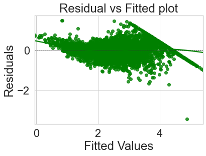

```python
sns.set_style("whitegrid")
sns.residplot(fitted, residual, color="green", lowess=True)
plt.xlabel("Fitted Values")
plt.ylabel("Residuals")
plt.title("Residual vs Fitted plot")
plt.show()
```

### Observation

**The trained model fits well for low to medium priced cars where the data is scattered evenly. For highly priced cars we can see a bias in the form of a backslash line pattern**

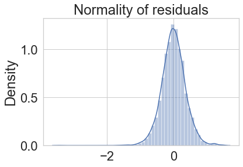

```python
sns.distplot(residual)
plt.title("Normality of residuals")
plt.show()
```

### Observation

**The residuals are normally distributed**

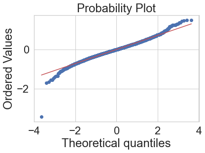

```python
import pylab
import scipy.stats as stats

stats.probplot(residual, dist="norm", plot=pylab)
plt.show()
```

### Observation

**The QQ plot of residuals can be used to visually check the normality assumption. The normal probability plot of residuals should approximately follow a straight line as evident from the above plot except for the lowest and high extremes**

```python
stats.shapiro(residual)
```

```
ShapiroResult(statistic=0.9845505952835083, pvalue=3.911545972610489e-23)
```

### Observation

**The residuals are not normal as per shapiro test, but as per QQ plot they are approximately normal.** **The issue with shapiro test is when dataset is big, even for small deviations, it shows data as not normal.** **Hence we go with the QQ plot and say that residuals are normal.**

### TEST FOR HOMOSCEDASTICITY

```python
import statsmodels.stats.api as sms
from statsmodels.compat import lzip

name = ["F statistic", "p-value"]
test = sms.het_goldfeldquandt(residual, X_train2)
lzip(name, test)
```

```
[('F statistic', 1.0529590126523565), ('p-value', 0.09769287611412958)]
```

### Obsevations

**Since p-value > 0.05, we can say that the residuals are homoscedastic. This assumption is therefore valid in the data.**

```python
X_train2.columns
```

```
Index(['const', 'Year', 'Kilometers_Driven', 'Mileage_kmpl_kmkg', 'Power_bhp',
       'Fuel_Type_CNG', 'Fuel_Type_Diesel', 'Fuel_Type_LPG',
       'Fuel_Type_Petrol', 'Indian_Region_North', 'Indian_Region_South',
       'Indian_Region_West', 'Transmission_Manual', 'Seats_Count_Economy',
       'Seats_Count_Large', 'Owner_Type_Second & Above', 'Brand_Geo_Asian',
       'Brand_Geo_European'],
      dtype='object')
```

```python
# Selecting columns from test data that we used to create our final model
X_test_final = X_test[X_train2.columns]
```

```python
# Checking model performance on train set (seen 70% data)
print("Train Performance\n")
model_perf(olsres2, X_train2.values, y_train)
```

```
Train Performance
```

|  | MAE | MAPE | RMSE | R^2 |
| --- | --- | --- | --- | --- |
| 0 | 1.537751 | 24.199816 | 2.23368 | 0.849239 |

```python
# Checking model performance on test set (seen 70% data)b
print("Test Performance\n")
model_perf(olsres2, X_test_final.values, y_test)
```

```
Test Performance
```

|  | MAE | MAPE | RMSE | R^2 |
| --- | --- | --- | --- | --- |
| 0 | 1.493022 | 23.876205 | 2.1609 | 0.851025 |

```python
# let us print the model summary

olsmod4 = sm.OLS(y_train, X_train2)
olsres4 = olsmod4.fit()
print(olsres4.summary())
```

```
                            OLS Regression Results
==============================================================================
Dep. Variable:             Sqrt_Price   R-squared:                       0.863
Model:                            OLS   Adj. R-squared:                  0.863
Method:                 Least Squares   F-statistic:                     1875.
Date:                Sat, 19 Jun 2021   Prob (F-statistic):               0.00
Time:                        06:10:34   Log-Likelihood:                -2051.8
No. Observations:                5073   AIC:                             4140.
Df Residuals:                    5055   BIC:                             4257.
Df Model:                          17
Covariance Type:            nonrobust
=============================================================================================
                                coef    std err          t      P>|t|      [0.025      0.975]
---------------------------------------------------------------------------------------------
const                      -205.2009      4.379    -46.861      0.000    -213.786    -196.616
Year                          0.1036      0.002     47.578      0.000       0.099       0.108
Kilometers_Driven         -2.651e-06   2.26e-07    -11.729      0.000   -3.09e-06   -2.21e-06
Mileage_kmpl_kmkg            -0.0260      0.002    -12.226      0.000      -0.030      -0.022
Power_bhp                     0.0105      0.000     52.634      0.000       0.010       0.011
Fuel_Type_CNG                -1.4666      0.368     -3.982      0.000      -2.189      -0.745
Fuel_Type_Diesel             -1.2274      0.364     -3.371      0.001      -1.941      -0.514
Fuel_Type_LPG                -1.4989      0.383     -3.910      0.000      -2.250      -0.747
Fuel_Type_Petrol             -1.6555      0.364     -4.551      0.000      -2.369      -0.942
Indian_Region_North           0.2002      0.022      9.201      0.000       0.158       0.243
Indian_Region_South           0.3119      0.019     16.328      0.000       0.274       0.349
Indian_Region_West            0.1954      0.020      9.722      0.000       0.156       0.235
Transmission_Manual          -0.2921      0.017    -17.580      0.000      -0.325      -0.260
Seats_Count_Economy          -0.0295      0.039     -0.762      0.446      -0.105       0.046
Seats_Count_Large             0.0784      0.044      1.778      0.076      -0.008       0.165
Owner_Type_Second & Above    -0.0671      0.014     -4.634      0.000      -0.096      -0.039
Brand_Geo_Asian               0.1546      0.021      7.499      0.000       0.114       0.195
Brand_Geo_European            0.2909      0.024     12.339      0.000       0.245       0.337
==============================================================================
Omnibus:                      337.965   Durbin-Watson:                   1.997
Prob(Omnibus):                  0.000   Jarque-Bera (JB):             1503.863
Skew:                          -0.142   Prob(JB):                         0.00
Kurtosis:                       5.652   Cond. No.                     5.49e+07
==============================================================================

Notes:
[1] Standard Errors assume that the covariance matrix of the errors is correctly specified.
[2] The condition number is large, 5.49e+07. This might indicate that there are
strong multicollinearity or other numerical problems.
```

### Observations

**Now adjusted R-squared is 0.863, i.e., our model is able to explain 86.3% of variance. This shows that the model is a good fit.** **The adjusted R-squared in olsres1 (where we considered all the variables) was 0.864. This shows that the variables we dropped were not affecting the model much.**